# Homework Summary

22058

2022-12-08

# Homework 0

## Question

Use knitr to produce at least 3 examples(texts, figures, tables).

## Answer

1. There is a dataset about **consumption** and **income**.

```r
set.seed(22058)
#Import data
data0 <- read.table("E:/Study/Graduate/Statistical_computing/Hw/Hw0/data.csv", sep=",", header=T)
summary(data0)
```

```
##   consumption        income
##  Min.   : 55.0   Min.   : 80.0
##  1st Qu.: 84.0   1st Qu.:120.0
##  Median :117.5   Median :172.5
##  Mean   :119.7   Mean   :173.2
##  3rd Qu.:141.0   3rd Qu.:225.0
##  Max.   :191.0   Max.   :270.0
```

```r
y <- as.matrix(data0[,1])#consumption
x <- as.matrix(data0[,2])#income
```

2. Draw a table of **consumption** and **income**.

```r
#Show the first six sets of data
knitr::kable(head(data0),align='c',caption="A Table of Consumption and Income")
```

A Table of Consumption and Income

| consumption | income |
| --- | --- |
| 55 | 80 |
| 65 | 100 |
| 70 | 85 |
| 80 | 110 |
| 79 | 120 |
| 84 | 115 |

```r
Table1 <- xtable::xtable(head(data0))
print(Table1,type="html")
```

|  | consumption | income |
| --- | --- | --- |
| 1 | 55 | 80 |
| 2 | 65 | 100 |
| 3 | 70 | 85 |
| 4 | 80 | 110 |
| 5 | 79 | 120 |
| 6 | 84 | 115 |

3. Draw some figures.

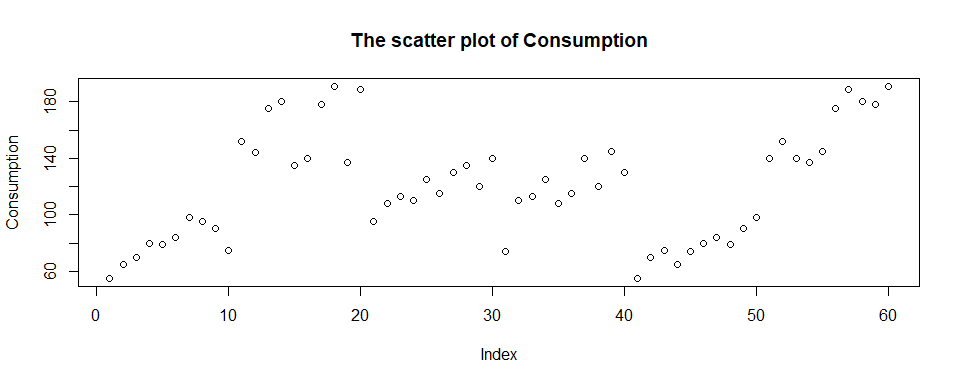

```r
#Draw the scatter plot of y(consumption)
plot(y,ylab="Consumption",main="The scatter plot of Consumption")
```

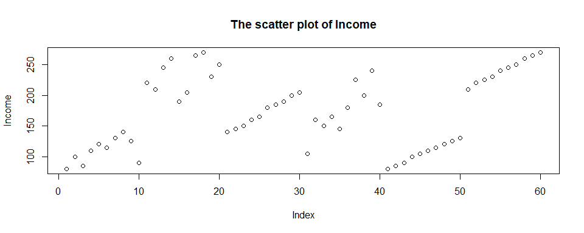

```r
#Draw the scatter plot of x(income)
plot(x,ylab="Income",main="The scatter plot of Income")
```

4. Linear regression of y(**consumption**) and x(**income**).

```r
lm1 <- lm(y~x)
summary(lm1)
```

```
##
## Call:
## lm(formula = y ~ x)
##
## Residuals:
##      Min       1Q   Median       3Q      Max
## -18.8734  -5.3131   0.9434   6.2774  20.3852
##
## Coefficients:
##             Estimate Std. Error t value Pr(>|t|)
## (Intercept)   9.3475     3.6384   2.569   0.0128 *
## x             0.6371     0.0199  32.009   <2e-16 ***
## ---
## Signif. codes:  0 '***' 0.001 '**' 0.01 '*' 0.05 '.' 0.1 ' ' 1
##
## Residual standard error: 9.032 on 58 degrees of freedom
## Multiple R-squared:  0.9464, Adjusted R-squared:  0.9455
## F-statistic:  1025 on 1 and 58 DF,  p-value: < 2.2e-16
```

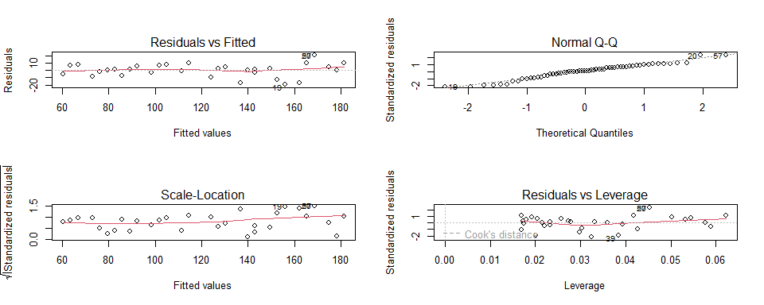

```r
par(mfrow=c(2,2))
plot(lm1)
```

```r
# Clean the memory of the variables
rm(list=ls())
```

The **regression equation** is
$$\hat{y}=0.6371x+9.3475.$$
—

# Homework 1

## Question 3.3

The $Pareto(a,b)$ distribution has cdf
$$F(x)=1-(\frac{b}{x})^a, x\geq
b>0,a>0.$$
Derive the probability inverse transformation $F^{-1}(U)$ and use the inverse transform method to simulate a random sample from the $Pareto(2,2)$ distribution. Graph the density histogram of the sample with the $Pareto(2,2)$ density superimposed for comparison.

## Answer3.3

There is
$$F(x)=1-(\frac{b}{x})^a, x\geq
b>0,a>0.$$
Generate random numbers $U\sim U(0,1)$
$$1-(\frac{b}{x})^a=U.$$
$$(\frac{b}{x})^a=1-U.$$
$$\frac{b}{x}=\sqrt[a]{1-U}.$$
$$X=\frac{b}{\sqrt[a]{1-U}}=F^{-1}(U).$$

When $a=2, b=2$, the cdf is
$$F(x)=1-(\frac{2}{x})^2, x\geq 2.$$
The pdf is
$$f(x)=\frac{8}{x^3}, x\geq 2.$$
$$F^{-1}(U)=\frac{2}{\sqrt[2]{1-U}}.$$

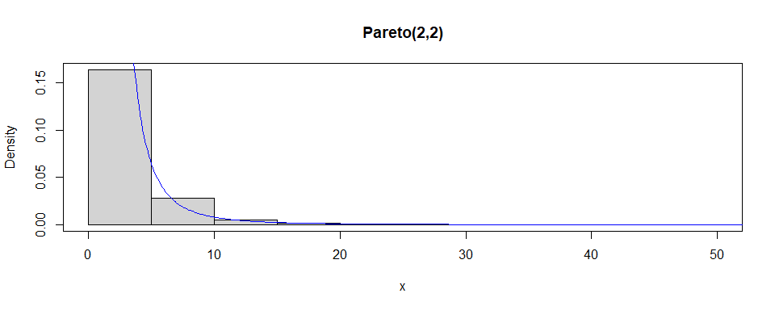

```r
set.seed(22058)
n <- 1000
u <- runif(n)#generate random numbers U~U(0,1)
x <- 2/(1-u)^{1/2}
#Graph the histogram of the random sample
hist(x, prob = TRUE, main="Pareto(2,2)", xlim=c(0,50))
box()
#Superimpose the theoretical density
y <- seq(2,100,0.1)
lines(y, 8/y^3, col="blue")
```

```r
# Clean the memory of the variables
rm(list=ls())
```

## Question 3.7

Write a function to generate a random sample of size n from the $Beta(a,b)$ distribution by the acceptance-rejection method. Generate a random sample of size 1000 from the $Beta(3,2)$ distribution. Graph the histogram of the sample with the theoretical $Beta(3,2)$ density superimposed.

## Answer3.7

The pdf of $Beta(a,b)$ is
$$f(x)=\frac{\Gamma(a+b)}{\Gamma(a)\Gamma(b)}x^{a-1}(1-x)^{b-1},
a,b>0,x\in(0,1).$$

**Case 1: $b=1$**

The pdf is
$$f(x)=\frac{\Gamma(a+1)}{\Gamma(a)\Gamma(1)}x^{a-1}=ax^{a-1},x\in(0,1).$$
So we can get the cdf
$$F(x)=\int_0^x
as^{a-1} ds=s^a|_0^x=x^a,x\in(0,1).$$

Generate $U\sim U(0,1)$, return the random number
$$X=F^{-1}(U)=\sqrt[a]{U}\sim
Beta(a,1)$$

**Case 2: $a=1,b\neq1$**

The pdf is
$$f(x)=b(1-x)^{b-1},x\in(0,1).$$

So we can get the cdf
$$F(x)=-(1-x)^b+1,x\in(0,1).$$

Generate $U\sim U(0,1)$, return the random number
$$X=F^{-1}(U)=1-\sqrt[b]{1-U}\sim
Beta(1,b).$$
$$\because U\sim
U(0,1)$$
$$\therefore 1-U\sim
U(0,1)$$
So the random number
$$X=1-\sqrt[b]{U}\sim Beta(1,b)$$

**Case 3: $a>1,b>1$**

Using the **acceptance-rejection method**. Choose
$$g(x)=1,0<x<1$$
to be the envelope function.
$$\because f(0)=0,f(1)=0$$
$$f^\prime(x)=\frac{\Gamma(a+b)}{\Gamma(a)\Gamma(b)}[(a-1)x^{a-2}(1-x)^{b-1}-x^{a-1}(b-1)(1-x)^{b-2}].$$
Let $f^\prime(x)=0$, we can get the maximum point $x=\frac{a-1}{a+b-2}$. So there is
$$sup(f(x))=f(\frac{a-1}{a+b-2})=\frac{\Gamma(a+b)}{\Gamma(a)\Gamma(b)}\frac{(a-1)^{a-1}(b-1)^{b-1}}{(a+b-2)^{a+b-2}}$$

Let $c=sup(f(x))$, then the algorithm is as follows

- Generate $X\sim U(0,1),U_1\sim U(0,1)$.
- if $U_1<\frac{f(x)}{c}$, return $X\sim Beta(a,b)$; otherwise reject $X$ and continue.

**Case 4: $a<1,b>1$**

Using the **acceptance-rejection method**. Choose
$$g(x)=ax^{a-1},0<x<1$$
to be the envelope function and $c=\frac{\Gamma(a+b)}{\Gamma(a)\Gamma(b)a}$.

Generate $U\sim U(0,1)$, then the random number
$$X=\sqrt[a]U\sim
g(x)$$

The algorithm is as follows

- Generate $U_1\sim U(0,1),U_2\sim U(0,1),X\leftarrow \sqrt[a]{U_2}$.
- if $U_1<\frac{f(x)}{cg(x)}=(1-x)^{b-1}$, return $X\sim Beta(a,b)$; otherwise reject $X$ and continue.

**Case 5: $a>1,b<1$**

Using the **acceptance-rejection method**. Choose
$$g(x)=b(1-x)^{b-1},0<x<1$$
to be the envelope function and $c=\frac{\Gamma(a+b)}{\Gamma(a)\Gamma(b)b}$.

Generate $U\sim U(0,1)$, then the random number
$$X=1-\sqrt[b]U\sim
g(x)$$

The algorithm is as follows

- Generate $U_1\sim U(0,1),U_2\sim U(0,1),X\leftarrow 1-\sqrt[b]{U_2}$.
- if $U_1<\frac{f(x)}{cg(x)}=x^{a-1}$, return $X\sim Beta(a,b)$; otherwise reject $X$ and continue.

**Case 6: $a<1,b<1$**

Using the **acceptance-rejection method**. Take $\frac{1}{2}$ as the dividing point and choose
$$g(x)=
\begin{cases}
(a+b-1)(2x)^{a+b-2},\quad 0<x\leq \frac{1}{2}\\
(a+b-1)(2-2x)^{a+b-2}, \quad \frac{1}{2}<x<1
\end{cases}$$
to be the envelope function and $c=\frac{\Gamma(a+b)}{\Gamma(a)\Gamma(b)(a+b-1)}(\frac{1}{2})^{a+b-2}$.

Generate $U\sim U(0,1)$. If $U\leq \frac{1}{2}$, then the random number
$$X=\sqrt[a+b-1]{\frac{U}{2^{a+b-2}}}\sim
g(x);$$
If $U> \frac{1}{2}$, then the random number
$$X=1-\sqrt[a+b-1]{\frac{1-U}{2^{a+b-2}}}\sim
g(x);$$

The algorithm is as follows

- Generate $U_1\sim U(0,1),U_2\sim U(0,1)$.
- if $U_1\leq \frac{1}{2}$, generate $X\leftarrow\sqrt[a+b-1]{\frac{U_1}{2^{a+b-2}}}$.
  - if $U_2<\frac{f(x)}{cg(x)}=(\frac{1}{x}-1)^{b-1}$, return $X\sim Beta(a,b)$; otherwise reject $X$ and continue.
- if $U_1> \frac{1}{2}$, generate $X\leftarrow1-\sqrt[a+b-1]{\frac{1-U_1}{2^{a+b-2}}}$.
  - if $U_2<\frac{f(x)}{cg(x)}=(\frac{1}{x}-1)^{1-a}$, return $X\sim Beta(a,b)$; otherwise reject $X$ and continue.

According to the derivation above, we use R to generate random numbers from the Beta(a,b) distribution for different cases(Case 1-6).

```r
set.seed(22058)
#The function to generate random numbers from Beta(a,b)
generate_beta = function(a,b){
  if(b==1){
    u <- runif(1)
    x <- u^(1/a) #Inverse transform method
  }else if(a==1&b!=1){
    u <- runif(1)
    x <- 1-u^(1/b) #Inverse transform method
  }else if(a>1&b>1){
    repeat{
      u1 <- runif(1)
      u2 <- runif(1)
      x <- u1
      a1 <- a-1;b1 <- b-1;ab <- a+b-2
      y <- u2*(gamma(a+b)*a1^a1*b1^b1)/(gamma(a)*gamma(b)*ab^ab)
      if(y<=dbeta(x,a,b))
        break
    }
  }else if(a<1&b>1){
    repeat{
      u1 <- runif(1)
      y <- runif(1)
      x <- u1^(1/a)
      if(y<=(1-x)^(b-1))
        break
    }
  }else if(a>1&b<1){
    repeat{
      u1 <- runif(1)
      y <- runif(1)
      x <- 1-u1^(1/b)
      if(y<=x^(a-1))
        break
    }
  }else{
    repeat{
      u1 <- runif(1)
      y <- runif(1)
      if(u1<=0.5){
        x <- (u1/2^(a+b-2))^(1/(a+b-1))
        if(y<=(1/x-1)^(b-1))
          break
      }else{
        x <- 1-((1-u1)/2^(a+b-2))^(1/(a+b-1))
        if(y<=(1/x-1)^(1-a))
          break
      }
    }
  }
  return(x)
}
```

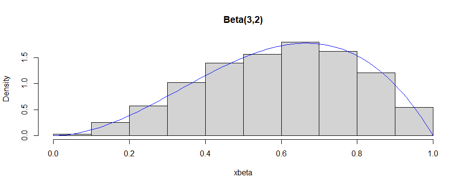

```r
n <- 1000
xbeta <- numeric(n)
for(i in 1:n){
  xbeta[i] <- generate_beta(3,2)
}
#Graph the histogram of the random sample
hist(xbeta, prob=TRUE, main="Beta(3,2)")
#Superimpose the theoretical Beta(3,2) density
curve(dbeta(x,3,2),col="blue",add=TRUE)
```

```r
# Clean the memory of the variables
rm(list=ls())
```

## Question 3.12

Simulate a continuous Exponential-Gamma mixture. Suppose that the rate parameter $\Lambda$ has Gamma($\gamma,\beta$) distribution and $Y$ has Exp($\Lambda$) distribution. That is, $(Y|\Lambda=\lambda)\sim f_Y(y|\lambda)=\lambda e^{−\lambda y}$. Generate 1000 random observations from this mixture with $\gamma=4$ and $\beta=2$.

## Answer 3.12

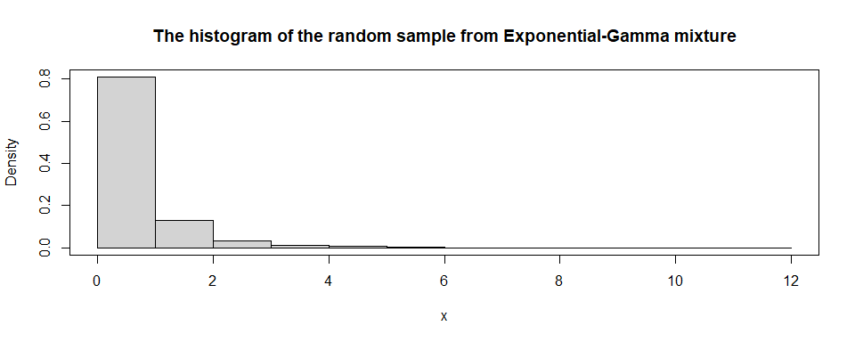

```r
set.seed(22058)
n <- 1000;r <- 4;beta <- 2
lambda <- rgamma(n,r,beta)
x <- rexp(n,lambda)
#Graph the histogram of the random sample
hist(x, prob = TRUE, main="The histogram of the random sample from Exponential-Gamma mixture")
box()
```

```r
# Clean the memory of the variables
rm(list=ls())
```

## Question 3.13

It can be shown that the mixture in Exercise 3.12 has a Pareto distribution with cdf
$$F(y)=1-(\frac{\beta}{\beta+y})^\gamma, y\geq
0.$$
(This is an alternative parameterization of the Pareto cdf given in Exercise 3.3.) Generate 1000 random observations from the mixture with $\gamma=4$ and $\beta=2$. Compare the empirical and theoretical (Pareto) distributions by graphing the density histogram of the sample and superimposing the Pareto density curve.

## Answer 3.13

When $\gamma=4$ and $\beta=2$, the cdf is
$$F(y)=1-(\frac{2}{2+y})^4, y\geq 0.$$
The pdf is
$$f(y)=\frac{64}{(2+y)^5}, y\geq
0.$$

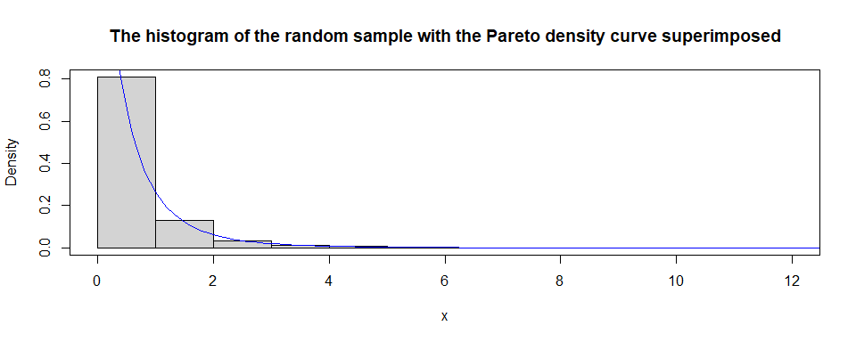

```r
set.seed(22058)
n <- 1000;r <- 4;beta <- 2
lambda <- rgamma(n,r,beta)
x <- rexp(n,lambda)
#Graph the histogram of the random sample
hist(x, prob = TRUE, main="The histogram of the random sample with the Pareto density curve superimposed")
y <- seq(0,100,0.1)
#Superimpose the theoretical density
lines(y, 64/(2+y)^5, col="blue")
box()
```

```r
# Clean the memory of the variables
rm(list=ls())
```

# Homework 2

## Question 1

- For $n=10^4$, $2×10^4$, $4×10^4$, $6×10^4$, $8×10^4$, apply the fast sorting algorithm to randomly permuted numbers of $1,...,n$.
- Calculate computation time averaged over 100 simulations, denoted by $a_n$.
- Regress $a_n$ on $t_n:= nlog(n)$, and graphically show the results(scatter plot and regression line).

## Answer 1

Using R to implement the fast sorting algorithm.

```r
set.seed(22058)
# The fast sorting function
fast_sort<-function(x){
  num<-length(x)
  if(num==0||num==1){return(x)
  }else{
    a<-x[1]
    y<-x[-1]
    lower<-y[y<a]
    upper<-y[y>=a]
    return(c(fast_sort(lower),a,fast_sort(upper)))}
}

# Apply the fast sorting function
n1=1e4;n2=2e4;n3=4e4;n4=6e4;n5=8e4
test1<-sample(1:n1)
test2<-sample(1:n2)
test3<-sample(1:n3)
test4<-sample(1:n4)
test5<-sample(1:n5)

# 100 simulations
y1 <- y2 <- y3 <- y4 <- y5 <- numeric(100)
for(i in 1:100){
  y1[i] <- system.time(fast_sort(test1))[1]
  y2[i] <- system.time(fast_sort(test2))[1]
  y3[i] <- system.time(fast_sort(test3))[1]
  y4[i] <- system.time(fast_sort(test4))[1]
  y5[i] <- system.time(fast_sort(test5))[1]
}
# Calculate the average of computation time
a1 <- mean(y1)
a2 <- mean(y2)
a3 <- mean(y3)
a4 <- mean(y4)
a5 <- mean(y5)
a <- c(a1,a2,a3,a4,a5)
# Calculate the theoretical computation time
t1 <- n1*log(n1)
t2 <- n2*log(n2)
t3 <- n3*log(n3)
t4 <- n4*log(n4)
t5 <- n5*log(n5)
t <- c(t1,t2,t3,t4,t5)

# Regression about Simulated computation time and Theoretical computation time
lm1 <- lm(a~t)
summary(lm1)
```

```
##
## Call:
## lm(formula = a ~ t)
##
## Residuals:
##          1          2          3          4          5
## -0.0012054  0.0009520  0.0007524 -0.0002229 -0.0002760
##
## Coefficients:
##              Estimate Std. Error t value Pr(>|t|)
## (Intercept) 2.777e-03  8.253e-04   3.365   0.0436 *
## t           2.175e-07  1.518e-09 143.287  7.5e-07 ***
## ---
## Signif. codes:  0 '***' 0.001 '**' 0.01 '*' 0.05 '.' 0.1 ' ' 1
##
## Residual standard error: 0.001009 on 3 degrees of freedom
## Multiple R-squared:  0.9999, Adjusted R-squared:  0.9998
## F-statistic: 2.053e+04 on 1 and 3 DF,  p-value: 7.495e-07
```

We can get that the linear relationship between **simulated computation time** and **theoretical computation time** is significant.

Show the results through figures(**the scatter plot** with **the regression line** superimposed).

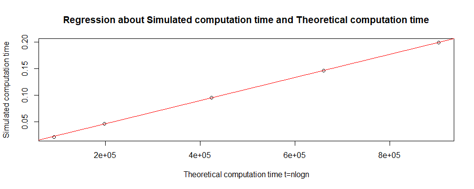

```r
# Draw the scatter plot
plot(t,a,main="Regression about Simulated computation time and Theoretical computation time",xlab="Theoretical computation time t=nlogn",ylab="Simulated computation time")
# Superimpose the regression line
abline(lm1,col="red")
```

```r
# Clean the memory of the variables
rm(list=ls())
```

## Question 5.6

In Example 5.7 the control variate approach was illustrated for Monte Carlo integration of
$$\theta=\int_0^1 e^{x}
dx.$$
Now consider the antithetic variate approach. Compute $Cov(e^U,e^{1−U})$ and $Var(e^U+e^{1−U})$, where $U\sim Uniform(0,1)$. What is the percent reduction in variance of $\hatθ$ that can be achieved using antithetic variates (compared with simple MC)?

## Answer 5.6

$$\theta=\int_0^1 e^{x}
dx=E(e^{x})=E(\frac{e^{x}+e^{1-x}}{2}),x\sim U(0,1).$$

- The antithetic variate method
  - Specify $N$, the number of simulations;
  - Generate random numbers $X_1,..., X_N$ from the uniform distribution U(0,1);
  - Calculate the antithetic variable estimator of $\theta$
    $$\hat{\theta}=\frac{1}{N}\sum_{i=1}^{N/2}(e^{U}+e^{1-U}),U\sim
    U(0,1).$$
  - Output result $\hat{\theta}.$
- So the variance of $\hat{\theta}$ is

$$\begin{align*}
Var(\hat{\theta})=&Var(\frac{1}{N}\sum_{i=1}^{N/2}(e^{U}+e^{1-U}))\\
=&\frac{1}{N^2}\frac{N}{2}Var(e^{U}+e^{1-U})\\
=&\frac{1}{2N}(Var(e^{U})+Var(e^{1-U})+2Cov(e^{U},e^{1-U}))\\
=&\frac{1}{N}(Var(e^{U})+Cov(e^{U},e^{1-U})),U\sim U(0,1).
\end{align*}$$

- The simple MC method
  - Specify $N$, the number of simulations;
  - Generate random numbers $X_1,..., X_N$ from the uniform distribution U(0,1);
  - Calculate the simple MC estimator of $\theta$
    $$\hat{\theta}'=\frac{1}{N}\sum_{i=1}^{N}e^{U},U\sim
    U(0,1).$$
  - Output result $\hat{\theta}'.$
- So the variance of $\hat{\theta}'$ is

$$\begin{align*}
Var(\hat{\theta}')=&Var(\frac{1}{N}\sum_{i=1}^{N}e^{U})\\
=&\frac{1}{N}Var(e^{U})\\
=&\frac{1}{N}(E(e^{2U})-[E(e^{U})]^2),U\sim U(0,1).
\end{align*}$$

- Compute $Cov(e^U,e^{1−U})$ and $Var(e^U+e^{1−U})$, $U\sim U(0,1)$.

$$\begin{align*}
Cov(e^{U},e^{1-U})
=&E(e^{U}e^{1-U})-E(e^{U})E(e^{1-U})\\
=&e-[E(e^{U})]^2.
\end{align*}$$
$$\begin{align*}
Var(e^{U}+e^{1-U})=&Var(e^{U})+Var(e^{1-U})+2Cov(e^{U},e^{1-U})\\
=&2Var(e^{U})+2Cov(e^{U},e^{1-U})\\
=&2E(e^{2U})-4[E(e^{U})]^2+2e.
\end{align*}$$
$$\because U\sim U(0,1)$$
$$\therefore E(e^{U})=\int_{0}^{1}e^U
dU=e^U|_{0}^{1}=e-1$$
$$\therefore
E(e^{2U})=\int_{0}^{1}e^{2U}
dU=\frac{1}{2}e^{2U}|_{0}^{1}=\frac{1}{2}(e^2-1)$$
$$\therefore Cov(e^{U},e^{1-U})=-e^2+3e-1$$
$$\therefore
Var(e^{U}+e^{1-U})=-3e^2+10e-5$$

```r
set.seed(22058)
# The theoretical value of Cov(e^U,e^(1-U))
cov1 <- -exp(2)+3*exp(1)-1
cat("The theoretical covariance is",cov1,"\n")
```

```
## The theoretical covariance is -0.2342106
```

```r
# The theoretical value of Var(e^U+e^(1-U))
var1 <- -3*exp(2)+10*exp(1)-5
cat("The theoretical variance is",var1,"\n")
```

```
## The theoretical variance is 0.01564999
```

- Compute empirical estimates of $Cov(e^U,e^{1−U})$ and $Var(e^U+e^{1−U})$.

```r
N <- 10000
U1 <- runif(N/2)
y11 <- exp(U1)
y12 <- exp(1-U1)
cat("The empirical estimate of covariance is",cov(y11,y12))
```

```
## The empirical estimate of covariance is -0.2330859
```

```r
y1 <- y11+y12
cat("The empirical estimate of variance",var(y1))
```

```
## The empirical estimate of variance 0.01552064
```

- According to the output, the empirical estimates of $Cov(e^U,e^{1−U})$ and $Var(e^U+e^{1−U})$ are close to the theoretical values.
- Compute the percent reduction in variance of $\hatθ$.

$$\begin{align*}
Var(\hat{\theta}')-Var(\hat{\theta})=&-\frac{1}{N}Cov(e^{U},e^{1-U})\\
=&-\frac{1}{N}(-e^2+3e-1).
\end{align*}$$

- So the percent reduction in variance is

$$\begin{align*}
\frac{Var(\hat{\theta}')-Var(\hat{\theta})}{Var(\hat{\theta}')}=&\frac{-\frac{1}{N}(-e^2+3e-1)}{\frac{1}{N}(E(e^{2U})-[E(e^{U})]^2)}\\
=&\frac{-(-e^2+3e-1)}{\frac{1}{2}(e^2-1)-(e-1)^2}\\
=&\frac{-6e+2e^2+2}{-e^2+4e-3}
\end{align*}$$

```r
# The theoretical percent reduction in variance
reducper <- (-6*exp(1)+2*exp(2)+2)/(-exp(2)+4*exp(1)-3)
cat("The theoretical percent reduction in variance is",reducper,"\n")
```

```
## The theoretical percent reduction in variance is 0.9676701
```

```r
# Clean the memory of the variables
rm(list=ls())
```

## Question 5.7

Refer to Exercise 5.6. Use a Monte Carlo simulation to estimate $\theta$ by the antithetic variate approach and by the simple Monte Carlo method. Compute an empirical estimate of the percent reduction in variance using the antithetic variate. Compare the result with the theoretical value from Exercise 5.6.

## Answer 5.7

```r
set.seed(22058)
# The antithetic variate method
antithetic <- function(N){
  U <- runif(N/2)
  y <- c(exp(U),exp(1-U))
  return(mean(y))
}
# The simple MC method
simpleMC <- function(N){
  U <- runif(N)
  y <- exp(U)
  return(mean(y))
}

N <- 10000
m <- 100
# m simulations
Est1 <- Est2 <- numeric(m)
for(i in 1:m){
  Est1[i] <- antithetic(N)
  Est2[i] <- simpleMC(N)
}

cat(" The antithetic variable estimator is",mean(Est1),"\n","The simple MC estimator is",mean(Est2),"\n")
```

```
##  The antithetic variable estimator is 1.718234
##  The simple MC estimator is 1.718964
```

- Compute the percent reduction in variance.

```r
# The variance of the antithetic variate method
var1 <- var(Est1)
# The variance of the simple MC
var2 <- var(Est2)
# The empirical estimate of the percent reduction in variance
cat("The empirical estimate of the percent reduction in variance is",(var2-var1)/var2,"\n")
```

```
## The empirical estimate of the percent reduction in variance is 0.9608478
```

```r
# Clean the memory of the variables
rm(list=ls())
```

- According to the output, the empirical estimate of the percent reduction in variance is close to the theoretical value from Exercise 5.6.

# Homework 3

## Exercise 5.13

Find two importance functions $f_1$ and $f_2$ that are supported on $(1,\infty)$ and are ‘close’ to
$$g(x)=\frac{x^2}{\sqrt{2\pi}}e^{-x^2/2},x>1.$$
Which of your two importance functions should produce the smaller variance in estimating
$$\int_{1}^{\infty}\frac{x^2}{\sqrt{2\pi}}e^{-x^2/2}dx$$
by importance sampling? Explain.

## Answer 5.13

- Choose the importance function

  $$f_1(x)=\sqrt{\frac{2}{\pi}}e^{\frac{-(x-1)^2}{2}}=2*\frac{1}{\sqrt{2\pi}}e^{\frac{-(x-1)^2}{2}},x>1.$$

  We can generate random numbers from density $f_1(x)$ by following these steps:
  - Specify $n$, the size of random sample;
  - Generate random numbers $X_1,..., X_n$ from normal distribution $N(0,1)$;
  - Let $Z_i=|X_i|+1,i=1,2,\dots,n$, so we can get that $Z_i\sim f_1(x),i=1,2,\dots,n$.

  $$I=\int_{1}^{\infty}g(x)dx=\int_{1}^{\infty}\frac{g(x)}{f_1(x)}f_1(x)dx=E[\frac{g(x)}{f_1(x)}],x\sim
  f_1(x)$$

  So the algorithm is as follows,
  - Specify $N$, the number of simulations;
  - Generate random numbers $X_1,..., X_N$ from density $f_1(x)$;
  - Calculate the estimator

    $$\hat{I}=\frac{1}{N}\sum_{i=1}^{N}\frac{g(X_i)}{f_1(X_i)}$$
  - Output result $\hat{I}$.
- Choose the importance function $f_2(x)=xe^{\frac{-x^2+1}{2}},x>1$.

  $$\begin{align*}
  F(x)=&\int_{1}^{x}f_2(x)dx\\
  =&\int_{1}^{x}xe^{\frac{-x^2+1}{2}}dx\\
  =&-e^{\frac{-x^2+1}{2}}|_1^x\\
  =&1-e^{\frac{-x^2+1}{2}}
  \end{align*}$$
  $$\because U\sim U(0,1),1-U\sim
  U(0,1)$$
  $$F(x)=U,F^{-1}(U)=\sqrt{1-2log(1-U)}\sim
  f_2(x)$$
  $$\therefore
  F^{-1}(U)=\sqrt{1-2log(U)}\sim f_2(x)$$
  Therefore, we can generate random numbers from density $f_2(x)$ according to the above procedure.

  $$I=\int_{1}^{\infty}g(x)dx=\int_{1}^{\infty}\frac{g(x)}{f_2(x)}f_2(x)dx=E[\frac{g(x)}{f_2(x)}],x\sim
  f_2(x)$$
  So the algorithm is as follows,
  - Specify $N$, the number of simulations;
  - Generate random numbers $X_1,..., X_N$ from density $f_2(x)$;
  - Calculate the estimator

    $$\hat{I}=\frac{1}{N}\sum_{i=1}^{N}\frac{g(X_i)}{f_2(X_i)}$$
  - Output result $\hat{I}$.
- Draw the curves of $g(x)$, $f_1(x)$ and $f_2(x)$.

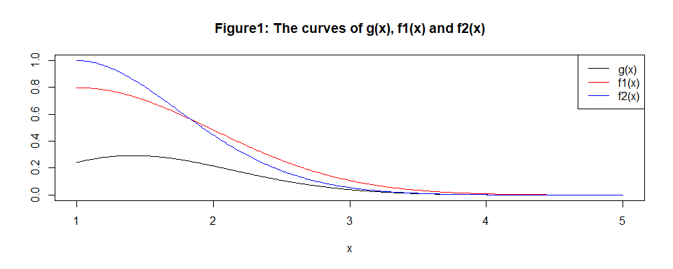

```r
set.seed(22058)
x <- seq(1,5,0.01)
g <- x^2*exp(-x^2/2)/(2*pi)^0.5
f1 <- (2/pi)^0.5*exp(-(x-1)^2/2)
f2 <- x*exp((1-x^2)/2)
plot(x,g,ylim=c(0,1),lty=1,type="l",ylab="",main="Figure1: The curves of g(x), f1(x) and f2(x)")
lines(x,f1,col="red",lty=1)
lines(x,f2,col="blue",lty=1)
legend("topright",c("g(x)","f1(x)","f2(x)"),lty=c(1,1,1),col=c("black","red","blue"))
```

- The variance of $\hat{I}$ is

  $$\begin{align*}
  Var(\hat{I})=&\frac{1}{N}Var(\frac{g(X)}{f(X)}),X\sim f(x)\\
  =&\frac{1}{N}(E[(\frac{g(X)}{f(X)})^2]-(E[\frac{g(X)}{f(X)}])^2)\\
  =&\frac{1}{N}(\int_1^\infty\frac{g^2(x)}{f(x)}dx-I^2)
  \end{align*}$$
  while the function $f(x)$ is the importance function. The minimum variance is obtained when

  $$f(x)=\frac{|g(x)|}{\int_1^\infty|g(x)|dx}.$$
  Therefore, the shape of the density $f(x)$ is closer to $|g(x)|$, the variance $Var(\hat I)$ is smaller.

  According to the curves of $g(x)$, $f_1(x)$ and $f_2(x)$(**Figure1**), the shape of $f_1(x)$ is closer to $g(x)$ than $f_2(x)$, implying that we will get the smaller variance in estimating by using the importance function $f_1(x)$.
- Using the two importance function to estimate the integral $I=\int_{1}^{\infty}g(x)dx$.

```r
set.seed(22058)
# The function of g(x)
g <- function(x){
  return(x^2*exp(-x^2/2)/(2*pi)^0.5)
}

# The importance function f1
f1 <- function(x){
  return((2/pi)^0.5*exp(-(x-1)^2/2))
}
# The function to generate random numbers from f1
f1sample <- function(N){
  x <- rnorm(N)
  z <- abs(x)+1
  return(z)
}
# The importance sampling function of f1
importancef1 <- function(N){
  x <- f1sample(N)
  y <- g(x)/f1(x)
  return(mean(y))
}

# The importance function f2
f2 <- function(x){
  return(x*exp((1-x^2)/2))
}
# The function to generate random numbers from f2
f2sample <- function(N){
  U <- runif(N,0,1)
  x <- (1-2*log(U))^0.5
  return(x)
}
# The importance sampling function of f2
importancef2 <- function(N){
  x <- f2sample(N)
  y <- g(x)/f2(x)
  return(mean(y))
}

n <- 100 # The number of simulations
N <- 1000 # The size of random sample
y1 <- y2 <- numeric(n)
for(i in 1:n){
  y1[i] <- importancef1(N)
  y2[i] <- importancef2(N)
}
cat(" The estimator using f1 is",mean(y1),";","\n",
    "The variance is",var(y1),".")
```

```
##  The estimator using f1 is 0.4006474 ;
##  The variance is 1.631082e-06 .
```

```r
cat(" The estimator using f2 is",mean(y2),";","\n",
    "The variance is",var(y2),".")
```

```
##  The estimator using f2 is 0.4005715 ;
##  The variance is 1.746881e-05 .
```

```r
# Clean the memory of the variables
rm(list=ls())
```

- According to the output, the variance in estimating is smaller by using the importance function $f_1(x)$.

## Exercise 5.15

Obtain the stratified importance sampling estimate in Example 5.13 and compare it with the result of Example 5.10.

## Answer 5.15

- We need to use the stratified importance sampling method to estimate the integral

  $$I=\int_0^1\frac{e^{-x}}{1+x^2}dx.$$
  Let
  $$g(x)=\frac{e^{-x}}{1+x^2}.$$

  Now divide the interval $(0,1)$ into five subintervals $(\frac{j}{5},\frac{j+1}{5}),j=0,1,\dots,4$. So there is
  $$I=\sum_{j=0}^{4}\int_{\frac{j}{5}}^{\frac{j+1}{5}}g(x)dx.$$
  Using importance sampling method on the five subintervals respectively. Then on the $j^{th}$ subinterval variables are generated from the density
  $$\begin{align*}
  f_j(x)=&\frac{e^{-x}}{\int_{\frac{j}{5}}^{\frac{j+1}{5}}e^{-x}dx}=\frac{e^{-x}}{-e^{-x}|_{\frac{j}{5}}^{\frac{j+1}{5}}}\\
  =&\frac{e^{\frac{j}{5}-x}}{1-e^{-\frac{1}{5}}},\frac{j}{5}<x<\frac{j+1}{5},j=0,1,\dots,4
  \end{align*}$$
  $$\begin{align*}
  F_j(x)=&\int_{\frac{j}{5}}^x\frac{e^{\frac{j}{5}-x}}{1-e^{-\frac{1}{5}}}=-\frac{e^{\frac{j}{5}-x}}{1-e^{-\frac{1}{5}}}|_{\frac{j}{5}}^x\\
  =&\frac{1-e^{\frac{j}{5}-x}}{1-e^{-\frac{1}{5}}},\frac{j}{5}<x<\frac{j+1}{5},j=0,1,\dots,4
  \end{align*}$$
  $$\because U\sim
  U(0,1),F_j(x)=U$$
  $$F_j^{-1}(U)=\frac{j}{5}-log(1-(1-e^{-\frac{1}{5}})U)\sim
  f_j(x)$$
  Therefore, we can generate random numbers from density $f_j(x)$ according to the above procedure.

  $$\begin{align*}
  I=&\sum_{j=0}^{4}\int_{\frac{j}{5}}^{\frac{j+1}{5}}g(x)dx=\sum_{j=0}^{4}\int_{\frac{j}{5}}^{\frac{j+1}{5}}\frac{g(x)}{f_j(x)}f_j(x)dx\\
  =&\sum_{j=0}^{4}E[\frac{g(x)}{f_j(x)}],x\sim f_j(x).
  \end{align*}$$
- So the algorithm is as follows,
  - Specify $N$, the number of simulations;
  - Generate random numbers $X_{1j},..., X_{\frac{N}{5},j}$ from density $f_j(x),j=0,1,\dots,4$;
  - Calculate the estimator

    $$\hat{I}=\frac{5}{N}\sum_{j=0}^{4}\sum_{i=1}^{N/5}\frac{g(X_{ij})}{f_j(X_{ij})}$$
  - Output result $\hat{I}$.
- Using the stratified importance sampling method to estimate the integral $I$.

```r
set.seed(22058)
M <- 1000 # The number of replicates
k <- 5 # The number of stratum
r <- M/k # Replicates per stratum
n <- 10 # The number of simulation

g <- function(x){
  return(exp(-x)/(1+x^2))
}
# The importance function for each stratum
fj <- function(x,j){
  return(exp(j/5-x)/(1-exp(-1/5)))
}
# The function to generate random numbers from fj
fjsample <- function(N,j){
  U <- runif(N,0,1)
  x <- j/5-log(1-(1-exp(-1/5))*U)
  return(x)
}
# The importance sampling for the jth subinterval
importancefj <- function(N,j){
  x <- fjsample(N,j)
  y <- g(x)/fj(x,j)
  return(mean(y))
}

# The stratified importance sampling
Est <- numeric(n)
Estj <- numeric(k)
for(i in 1:n){
  for (j in 1:k){
    Estj[j] <- importancefj(r,j-1)
  }
  Est[i] <- sum(Estj)
}

cat(" The estimator is",mean(Est),";","\n",
    "The standard deviation is",sd(Est),".")
```

```
##  The estimator is 0.5246062 ;
##  The standard deviation is 0.000530544 .
```

```r
# Clean the memory of the variables
rm(list=ls())
```

- Compared with the result of Example 5.10, the standard deviation of the stratified importance sampling method is much smaller.

# Homework 4

## Exercise 6.4

Suppose that $X_1,...,X_n$ are a random sample from a lognormal distribution with unknown parameters. Construct a 95% confidence interval for the parameter $\mu$. Use a Monte Carlo method to obtain an empirical estimate of the confidence level.

## Answer 6.4

- $X_1,...,X_n$ are a random sample from a lognormal distribution. Let $Y=\ln{X};Y_i=\ln{X_i},i=1,2,...,n$, so we have

  $$Y_i=\ln{X_i} \sim
  N(\mu,\sigma^2),i=1,2,...,n$$
  while $\mu$ and $\sigma$ are unknown.
  $$\therefore E(Y)=\mu,Var(Y)=\sigma^2$$
  therefore the estimator of $\mu$ is
  $$\hat{\mu}=\bar{Y}=\frac{1}{n}\sum_{i=1}^nY_i=\frac{1}{n}\sum_{i=1}^n\ln{X_i};$$
  the estimator of $\sigma^2$ is
  $$\hat{\sigma}^2=S^2=\frac{1}{n-1}\sum_{i=1}^n(Y_i-\bar{Y})^2$$
  $$\therefore \hat{\mu}\sim
  N(\mu,\frac{\sigma^2}{n}),\frac{(n-1)\hat\sigma^2}{\sigma^2}\sim
  \chi^2(n-1)$$
  $$\therefore
  \frac{\sqrt{n}(\hat{\mu}-\mu)}{\sigma}\sim
  N(0,1),\frac{\sqrt{n}(\hat{\mu}-\mu)}{\hat{\sigma}}\sim
  t(n-1)$$
- The 95% confidence interval for the parameter $\mu$ is

  $$[\hat{\mu}-\frac{t_{0.975}(n-1)\hat{\sigma}}{\sqrt{n}},\hat{\mu}+\frac{t_{0.975}(n-1)\hat{\sigma}}{\sqrt{n}}],$$
  i.e.
  $$[\frac{1}{n}\sum_{i=1}^n\ln{X_i}-\frac{t_{0.975}(n-1)S}{\sqrt{n}},\frac{1}{n}\sum_{i=1}^n\ln{X_i}+\frac{t_{0.975}(n-1)S}{\sqrt{n}}],$$

  while $t_{0.975}(n-1)$ is the 0.975 quantile of $t(n-1)$ distribution.
- Use a Monte Carlo method to obtain an empirical estimate of the confidence level.

  We set the real values $\mu=1$ and $\sigma=2$ there.

```r
set.seed(22058)
# Data generation
Generadata <- function(n){
  return(rnorm(n,1,2))
}

# Data analysis
# Calculate the 95% confidence interval
CL <- function(n,alpha){
  y <- Generadata(n)
  LCL <- mean(y)-sd(y)*qt(1-alpha/2,n-1)/(n)^0.5
  UCL <- mean(y)+sd(y)*qt(1-alpha/2,n-1)/(n)^0.5
  return(c(LCL,UCL))
}

# Result reporting
m <- 1000 # The number of simulation
n <- 50 # The size of random sample
alpha <- 0.05
CLvalue <- matrix(0,m,2) # Storage for 95% confidence interval
for(i in 1:m){
  CLvalue[i,] <- CL(n,alpha)
}
# Count the number of intervals that contain μ=1
count=0
for(i in 1:m){
  if(CLvalue[i,1]<1&&CLvalue[i,2]>1)
    count=count+1
}
# Calculate the empirical estimate of the confidence level
cat("The empirical estimate of the confidence level is",count/m)
```

```
## The empirical estimate of the confidence level is 0.956
```

```r
# Clean the memory of the variables
rm(list=ls())
```

- The empirical estimate of the confidence level is close to the theoretical value, 95%.

## Exercise 6.8

Refer to Example 6.16. Repeat the simulation, but also compute the $F$ test of equal variance, at significance level $\hat{\alpha} \doteq 0.055$. Compare the power of the Count Five test and $F$ test for small, medium, and large sample sizes. (Recall that the $F$ test is not applicable for non-normal distributions.)

## Answer 6.8

- Refer to Example 6.16: use Monte Carlo methods to estimate the power of the Count Five test and $F$ test.

```r
set.seed(22058)
# Data generation
# Generate samples under H1
sigma1 <- 1
sigma2 <- 1.5
m <- 1000 # The number of simulation
n <- c(20,200,2000) # The size of random sample

# Data analysis
# The function of Count Five test
count5test <- function(x, y) {
X <- x-mean(x)
Y <- y-mean(y)
outx <- sum(X > max(Y)) + sum(X < min(Y))
outy <- sum(Y > max(X)) + sum(Y < min(X))
return(as.integer(max(c(outx, outy))>5))
}

# Result reporting
count5power <- Fpower <- numeric(3)
for(i in 1:3){
  count5power[i] <- mean(replicate(m, expr={
    x <- rnorm(n[i], 0, sigma1)
    y <- rnorm(n[i], 0, sigma2)
    count5test(x, y)
    }))
}

for(i in 1:3){
  Fpvalues <- replicate(m, expr={
    x <- rnorm(n[i], 0, sigma1)
    y <- rnorm(n[i], 0, sigma2)
    Ftest <- var.test(x,y,1-0.055)
    Ftest$p.value
    })
  Fpower[i] <- mean(Fpvalues<=0.055)
}

Countdata <- data.frame(n,count5power)
knitr::kable(Countdata,align='c',
             caption="The powers of Count Five test for small, medium, and large sample sizes",
             col.names=c("Sample size","The power of Count Five test"))
```

The powers of Count Five test for small, medium, and large sample sizes

| Sample size | The power of Count Five test |
| --- | --- |
| 20 | 0.331 |
| 200 | 0.936 |
| 2000 | 0.999 |

```r
Fdata <- data.frame(n,Fpower)
knitr::kable(Fdata,align='c',
             caption="The powers of F test for small, medium, and large sample sizes",
             col.names=c("Sample size","The power of F test"))
```

The powers of F test for small, medium, and large sample sizes

| Sample size | The power of F test |
| --- | --- |
| 20 | 0.381 |
| 200 | 1.000 |
| 2000 | 1.000 |

```r
# Clean the memory of the variables
rm(list=ls())
```

- According to the output, F test is more powerful than the Count Five test for small sample size. In addition, the powers of the two tests are similar for medium and large sample sizes.

## Question 1

- If we obtain the powers for two methods under a particular simulation setting with 10000 experiments: say, 0.651 for one method and 0.676 for another method. Can we say the powers are different at 0.05 level?
  1. What is the corresponding hypothesis test problem?
  2. Which test can we use? Z-test, two-sample t-test, paired-t test or McNemar test? Why?
  3. Please provide the least necessary information for hypothesis testing.

## Answer 1

1. This is a hypothesis test about whether the powers for two method are equal. Let the power of one method is $p_1$, and another one is $p_2$. So the hypothesis is

$$H_0: p_1=p_2 \quad H_1: p_1 \neq
p_2$$

2. We can use McNemar test which is a matched pair test for $2 \times 2$ tables. The reasons are as follows:
- We apply the two methods under the same simulation setting, so the data obtained is paired.
- The definition of power is $P_{H_a}$(reject $H_0$), while
  - $H_0$ is the null hypothesis;
  - $H_a$ is the alternative hypothesis.

  The estimator of power is the proportion of reject $H_0$ in 10000 experiments under $H_a$ which can be taken as binary data. If an experiment reject $H_0$ under $H_a$, we denote it as $1$, otherwise denote it as $0$.Therefore we can list a $2\times2$ table and some equations:

|  |  | Method1 |  |
| --- | --- | --- | --- |
|  |  | 0 | 1 |
| Method2 | 0 | a | b |
|  | 1 | c | d |

$$\begin{cases}
b+d=6510\\
c+d=6760\\
a+b+c+d=10000
\end{cases}
\tag{1}$$

- If using Z-test, two-sample t-test or paired-t test, we need the hypothesis of normal distribution. However, we don’t need the hypothesis if we use McNemar test. So the effect of McNemar test will be better.
3. Under $H_0$, we have $c+d=b+d$ which means $b=c$. The test statistic is
   $$\chi^2=\frac{(b-c)^2}{b+c} \dot{\sim}
   \chi^2(1)$$
   Now we have the equations set$(1)$ above but four unknown parameters $a,b,c,d$. If one of the four parameters is known, the other three parameters will be known and we can complete the hypothesis testing. So we have to provide the information about at least one parameter for the hypothesis testing.

# Homework 5

## Exercise 7.4

Refer to the air-conditioning data set aircondit provided in the boot package. The 12 observations are the times in hours between failures of air-conditioning equipment [63, Example 1.1]:

$$3, 5, 7, 18, 43, 85, 91, 98, 100, 130,
230, 487.$$

Assume that the times between failures follow an exponential model Exp(λ). Obtain the MLE of the hazard rate λ and use bootstrap to estimate the bias and standard error of the estimate.

## Answer 7.4

The pdf of exponential distribution is
$$f(x)=\lambda e^{-\lambda
x},x>0.$$
We have 12 observations $X_i=x_i,i=1,2,...,12$. So the likelihood function is
$$L(x,\lambda)=\prod_{i=1}^{12}f(x_i)=\lambda^{12}e^{-\lambda\sum_{i=1}^{12}x_i}$$
$$\ln{L(x,\lambda)}=12\ln{\lambda}-\lambda\sum_{i=1}^{12}x_i$$
$$\frac{\partial{\ln{L(x,\lambda)}}}{\partial{\lambda}}=\frac{12}{\lambda}-\sum_{i=1}^{12}x_i=0$$
$$\frac{1}{\lambda}=\frac{1}{12}\sum_{i=1}^{12}x_i=\bar{x}$$

- The MLE of the hazard rate $\lambda$ is

  $$\hat{\lambda}=\frac{1}{\bar{x}}=0.00925$$
- Use bootstrap to estimate the bias and standard error of the estimate.

  $$X\sim
  Exp(\lambda),E[X]=\frac{1}{\lambda},\lambda=\frac{1}{E[X]}$$
  $$\therefore
  \hat{\lambda}=\frac{1}{\bar{X}},\bar{X}=\frac{1}{12}\sum_{i=1}^{12}X_i$$

```r
# Data generation
set.seed(22058)
data1 <- c(3,5,7,18,43,85,91,98,100,130,230,487)

# Data analysis
# Bootstrap
library(boot);library(MASS)
boot.lambda <- function(x,i) 1/mean(x[i])
obj <- boot(data=data1,statistic=boot.lambda,R=1e4)

# Result reporting
round(c(original=obj$t0,bias=mean(obj$t)-obj$t0,se=sd(obj$t)),5)
```

```
## original     bias       se
##  0.00925  0.00131  0.00427
```

```r
# Clean the memory of the variables
rm(list=ls())
```

## Exercise 7.5

Refer to Exercise 7.4. Compute 95% bootstrap confidence intervals for the mean time between failures 1/λ by the standard normal, basic, percentile, and BCa methods. Compare the intervals and explain why they may differ.

## Answer 7.5

```r
# Data generation
set.seed(22058)
data1 <- c(3,5,7,18,43,85,91,98,100,130,230,487)
ci.norm<-ci.basic<-ci.perc<-ci.bca<-numeric(2)

# Data analysis
library(boot)
boot.mean <- function(x,i) mean(x[i])
obj1 <- boot(data=data1,statistic=boot.mean,R=1000)
ci <- boot.ci(obj1,type=c("norm","basic","perc","bca"))
ci.norm<-ci$norm[2:3]
ci.basic<-ci$basic[4:5]
ci.perc<-ci$percent[4:5]
ci.bca<-ci$bca[4:5]
```

The 95% bootstrap confidence intervals for the mean time between failures by the standard normal, basic, percentile, and BCa methods are as follows.

```r
# Result reporting
cat(' standard normal:','[',ci.norm,']','\n',
    'basic:','[',ci.basic,']','\n',
    'percentile:','[',ci.perc,']','\n',
    'BCa:','[',ci.bca,']','\n')
```

```
##  standard normal: [ 32.22211 181.9421 ]
##  basic: [ 22.60662 165.9103 ]
##  percentile: [ 50.25635 193.56 ]
##  BCa: [ 58.8318 240.7572 ]
```

```r
# Clean the memory of the variables
rm(list=ls())
```

The original mean time between failures is $108.0833$. Under the same confidence level 95%, the interval lengths of standard normal, basic and percentile methods are close, while the interval length of BCa method is longer means lower accuracy.

Different method depends on different hypothesis, so the results of interval are different. Let $\hat{\theta},\hat{\theta}^*$ be the original estimator and the bootstrap estimator of $\theta$ respectively, and $X$ is the sample.

- The **standard normal** method is based on the hypothesis of asymptotic normality.
- The **basic** method is based on the hypothesis that $\hat{\theta}^*-\hat{\theta}|X$ and $\hat{\theta}-\theta$ have approximately the same distribution.
- The **percentile** method is based on the hypothesis that $\hat{\theta}^*|X$ and $\hat{\theta}$ have approximately the same distribution.
- The **BCa** method corrects the bias based on the percentile method.

## Exercise 7.A

Conduct a Monte Carlo study to estimate the coverage probabilities of the standard normal bootstrap confidence interval, the basic bootstrap confidence interval, and the percentile confidence interval.

Sample from a normal population and check the empirical coverage rates for the sample mean. Find the proportion of times that the confidence intervals miss on the left, and the proportion of times that the confidence intervals miss on the right.

## Answer 7.A

We suppose that the sample from $N(0,1)$ and the confidence level is 95%.

```r
# Data generation
n <- 20 # The size of random sample
m <- 1000 # The number of simulations

# Data analysis
set.seed(22058)
library(boot)
boot.mean <- function(x,i) mean(x[i])
ci.norm<-ci.basic<-ci.perc<-ci.bca<-matrix(NA,m,2)
for(i in 1:m){
  x <- rnorm(n)
  obj2 <- boot(data=x,statistic=boot.mean,R=1000)
  ci <- boot.ci(obj2,type=c("norm","basic","perc"))
  ci.norm[i,]<-ci$norm[2:3]
  ci.basic[i,]<-ci$basic[4:5]
  ci.perc[i,]<-ci$percent[4:5]
}
```

- The empirical coverage rates for the sample mean.

```r
# Result reporting
mu <- 0
# The empirical coverage rates
cat('norm =',mean(ci.norm[,1]<=mu & ci.norm[,2]>=mu),
    'basic =',mean(ci.basic[,1]<=mu & ci.basic[,2]>=mu),
    'perc =',mean(ci.perc[,1]<=mu & ci.perc[,2]>=mu))
```

```
## norm = 0.944 basic = 0.944 perc = 0.942
```

- The proportion of times that the confidence intervals miss on the left.

```r
cat('norm =',mean(ci.norm[,1]>mu),
    'basic =',mean(ci.basic[,1]>mu),
    'perc =',mean(ci.perc[,1]>mu))
```

```
## norm = 0.025 basic = 0.025 perc = 0.028
```

- The proportion of times that the confidence intervals miss on the right.

```r
cat('norm =',mean(ci.norm[,2]<mu),
    'basic =',mean(ci.basic[,2]<mu),
    'perc =',mean(ci.perc[,2]<mu))
```

```
## norm = 0.031 basic = 0.031 perc = 0.03
```

```r
# Clean the memory of the variables
rm(list=ls())
```

# Homework 6

## Exercise 7.8

Refer to Exercise 7.7. Obtain the jackknife estimates of bias and standard error of $\hat{\theta}$.

## Answer 7.8

```r
set.seed(22058)
library(bootstrap)

# Data analysis
# The function to compute the sample estimate of theta
thetaEst <- function(x){
  lambda.hat <- eigen(cov(x))$values
  return(lambda.hat[1]/sum(lambda.hat))
}
theta.hat <- thetaEst(scor) # The original statistic

# Jackknife
n <- nrow(scor)
theta.jack <- numeric(n)
for(i in 1:n){
  # The Jackknife statistic
  theta.jack[i] <- thetaEst(scor[-i,])
}
# The jackknife estimate of bias
bias.jack <- (n-1)*(mean(theta.jack)-theta.hat)
# The jackknife estimates of standard error
se.jack <- sqrt((n-1)*mean((theta.jack-mean(theta.jack))^2))

# Result reporting
round(c(original=theta.hat,
        bias.jack=bias.jack,
        se.jack=se.jack),3)
```

```
##  original bias.jack   se.jack
##     0.619     0.001     0.050
```

```r
# Clean the memory of the variables
rm(list=ls())
```

## Exercise 7.11

In Example 7.18, leave-one-out (n-fold) cross validation was used to select the best fitting model. Use leave-two-out cross validation to compare the models.

## Answer 7.11

```r
set.seed(22058)
library(DAAG)
attach(ironslag)
n <- length(magnetic)
e1 <- e2 <- e3 <- e4 <- matrix(NA,n*(n-1)/2,2)

# The function of four models
Jm <- function(J,x1,y1,s){
  if(s==1){# The first model
    yhat <- J1$coef[1] + J1$coef[2]*x1}
  else if(s==2){# The second model
    yhat <- J2$coef[1] + J2$coef[2]*x1 +J2$coef[3]*x1^2}
  else if(s==3){# The third model
    logyhat3 <- J3$coef[1] + J3$coef[2]*x1
    yhat <- exp(logyhat3)}
  else if(s==4){# The fourth model
    logyhat4 <- J4$coef[1] + J4$coef[2]*log(x1)
    yhat <- exp(logyhat4)}
  return(y1-yhat)
}

# Fit models on leave-two-out samples
k <- 1
for(i in 1:(n-1)){
  for(j in (i+1):n){
    y <- magnetic[-c(i,j)];x <- chemical[-c(i,j)]

    # The first model
    J1 <- lm(y ~ x)
    e1[k,] <- Jm(J1,chemical[c(i,j)],magnetic[c(i,j)],1)
    # The Second model
    J2 <- lm(y ~ x + I(x^2))
    e2[k,] <- Jm(J2,chemical[c(i,j)],magnetic[c(i,j)],2)
    # The third model
    J3 <- lm(log(y) ~ x)
    e3[k,] <- Jm(J3,chemical[c(i,j)],magnetic[c(i,j)],3)
    # The fourth model
    J4 <- lm(log(y) ~ log(x))
    e4[k,] <- Jm(J4,chemical[c(i,j)],magnetic[c(i,j)],4)

    k <- k+1
  }
}

# Result reporting
c(Model1=mean(e1^2), Model2=mean(e2^2), Model3=mean(e3^2), Model4=mean(e4^2))
```

```
##   Model1   Model2   Model3   Model4
## 19.57227 17.87018 18.45491 20.46718
```

According to the prediction error criterion, Model2, the quadratic model, would be the best fit for the data, which is same as the result of leave-one-out cross validation.

```r
M2 <- lm(magnetic ~ chemical + I(chemical^2))
summary(M2)
```

```
##
## Call:
## lm(formula = magnetic ~ chemical + I(chemical^2))
##
## Residuals:
##     Min      1Q  Median      3Q     Max
## -8.4335 -2.7006 -0.2754  2.5446 12.2665
##
## Coefficients:
##               Estimate Std. Error t value Pr(>|t|)
## (Intercept)   24.49262    9.14657   2.678   0.0100 **
## chemical      -1.39334    0.88852  -1.568   0.1232
## I(chemical^2)  0.05452    0.02081   2.620   0.0116 *
## ---
## Signif. codes:  0 '***' 0.001 '**' 0.01 '*' 0.05 '.' 0.1 ' ' 1
##
## Residual standard error: 4.098 on 50 degrees of freedom
## Multiple R-squared:  0.5931, Adjusted R-squared:  0.5768
## F-statistic: 36.44 on 2 and 50 DF,  p-value: 1.728e-10
```

The fitted regression equation for Model2 is
$$\hat{Y}=24.49262-1.39334X+0.05452X^2$$

```r
detach(ironslag)
# Clean the memory of the variables
rm(list=ls())
```

## Exercise 8.2

Implement the bivariate Spearman rank correlation test for independence [255] as a permutation test. The Spearman rank correlation test statistic can be obtained from function cor with method = “spearman”. Compare the achieved significance level of the permutation test with the p-value reported by cor.test on the same samples.

## Answer 8.2

Use permutation test and cor.test on the dataset **chickwts**.

```r
set.seed(22058)
# Data generation
attach(chickwts)
x <- as.vector(weight[feed == "sunflower"])
y <- as.vector(weight[feed == "linseed"])
detach(chickwts)

# Data analysis
R <- 999
K1 <- length(x);K2 <- length(y)
cors <- numeric(R)
# The permutation
cor0 <- cor(x,y,method="spearman")# The original statistic
for (i in 1:R) {
  k1 <- sample(1:K1, size = K1, replace = FALSE)
  k2 <- sample(1:K2, size = K2, replace = FALSE)
  x1 <- x[k1];y1 <- y[k2]
  # The permutation statistic
  cors[i] <- cor(x1,y1,method="spearman")
}
# The significance level of permutation
p <- mean(abs(c(cor0,cors))>=abs(cor0))

# Result reporting
c(permutation=p,
  cortest=cor.test(x,y,method="spearman")$p.value)
```

```
## permutation     cortest
##   0.4030000   0.4169384
```

```r
# Clean the memory of the variables
rm(list=ls())
```

According to the result, the achieved significance level of the permutation test is close to the p-value reported by cor.test.

# Homework 7

## Exercise 9.4

Implement a random walk Metropolis sampler for generating the standard Laplace distribution (see Exercise 3.2). For the increment, simulate from a normal distribution. Compare the chains generated when different variances are used for the proposal distribution. Also, compute the acceptance rates of each chain.

## Answer 9.4

- Random walk Metropolis sampling. Set different variances, $\sigma=0.05,0.5,2,16$.

```r
set.seed(22058)
# Target function: standard Laplace distribution
target <- function(x){
  return(0.5*exp(-abs(x)))
}

# Random walk Metropolis sampler
# Using a normal distribution as a proposal distribution
rw.Metropolis <- function(N,sigma,x0) {
  x <- numeric(N)
  x[1] <- x0
  u <- runif(N)
  k <- 0
  for (i in 2:N){
    y <- rnorm(1, x[i-1], sigma)
    A <- target(y)/target(x[i-1])
    if(u[i] <= A){
      x[i] <- y # Accept the new value
      k <- k+1
    }else{
      x[i] <- x[i-1] # Keep the old value
    }
  }
  return(list(x=x, k=k/N))
}

N <- 10000 # Length of chain
b <- 1000 # The Burn-in length
k <- 4 # The number of chain
sigma <- c(0.05,0.5,2,16)
x0 <- c(5,10,25,35)
rw1 <- rw.Metropolis(N,sigma[1],x0[3])
rw2 <- rw.Metropolis(N,sigma[2],x0[3])
rw3 <- rw.Metropolis(N,sigma[3],x0[3])
rw4 <- rw.Metropolis(N,sigma[4],x0[3])

# Result reporting
# The acceptance rates of each chain
print(c(sigma0.05=rw1$k,sigma0.5=rw2$k,sigma2=rw3$k,sigma16=rw4$k))
```

```
## sigma0.05  sigma0.5    sigma2   sigma16
##    0.9804    0.8352    0.5204    0.0982
```

- Monitor the convergence of the chains. For $\sigma=0.5$ and $\sigma=2$, setting the different initial value $x_0=5,10,25,35$.

```r
# The Gelman-Rubin method
Gelman.Rubin <- function(psi) {
  # psi[i,j] is the statistic psi(X[i,1:j])
  # for chain in i-th row of X
  psi <- as.matrix(psi)
  n <- ncol(psi);k <- nrow(psi)
  psi.means <- rowMeans(psi)
  B <- n*var(psi.means) # between variance est.
  psi.w <- apply(psi,1,"var") # within variances
  W <- mean(psi.w) # within est.
  v.hat <- W*(n-1)/n+(B/n) # upper variance est.
  r.hat <- v.hat/W # G-R statistic
  return(r.hat)
}

# Compute diagnostic statistics
chains1 <- chains2 <- matrix(0,k,N)
for(i in 1:k){
  chains1[i,] <- rw.Metropolis(N,sigma[2],x0[i])$x
  chains2[i,] <- rw.Metropolis(N,sigma[3],x0[i])$x
}
psi1 <- t(apply(chains1, 1, cumsum))
psi2 <- t(apply(chains2, 1, cumsum))
for(i in 1:nrow(psi1)){
  psi1[i,] <- psi1[i,]/(1:ncol(psi1))
}
for(i in 1:nrow(psi2)){
  psi2[i,] <- psi2[i,]/(1:ncol(psi2))
}
print(c(sigma0.5=Gelman.Rubin(psi1),sigma2=Gelman.Rubin(psi2)))
```

```
## sigma0.5   sigma2
## 1.141217 1.045901
```

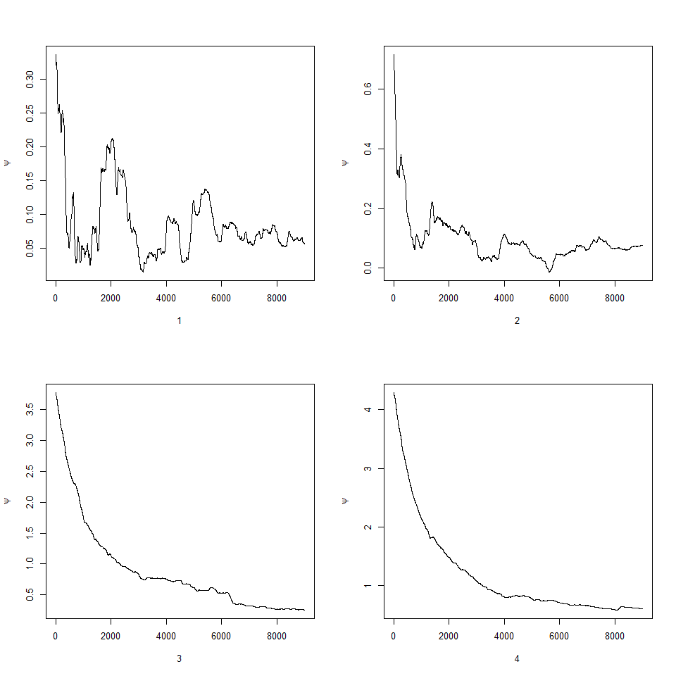

```r
# Plot psi for the four chains
par(mfrow=c(2,2))
# Sigma=0.5
for(i in 1:k){
  plot(psi1[i,(b+1):N],type="l",xlab=i,ylab=bquote(psi))
}
```

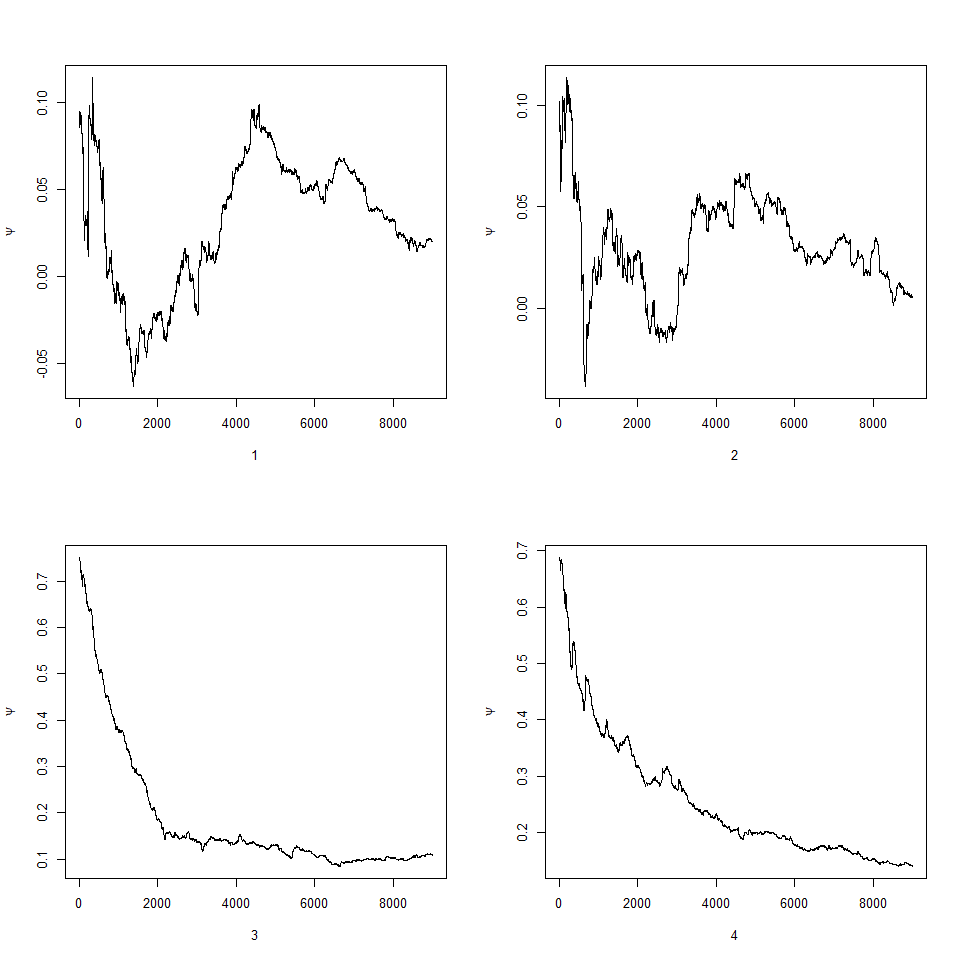

```r
# Sigma=2
for(i in 1:k){
  plot(psi2[i,(b+1):N],type="l",xlab=i,ylab=bquote(psi))
}
```

```r
par(mfrow=c(1,1)) #restore default
```

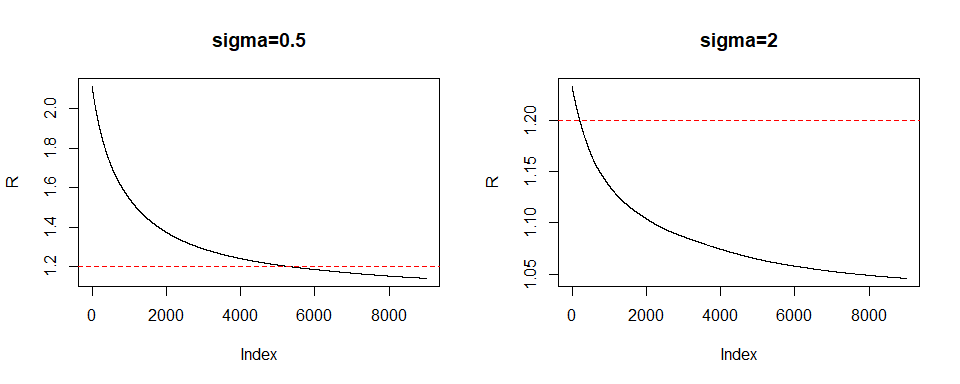

```r
#plot the sequence of R-hat statistics
rhat1 <- rhat2 <- rep(0,N)
for (j in (b+1):N){
  rhat1[j] <- Gelman.Rubin(psi1[,1:j])
  rhat2[j] <- Gelman.Rubin(psi2[,1:j])
}
par(mfrow=c(1,2))
# Sigma=0.5
plot(rhat1[(b+1):N], type="l", main="sigma=0.5", ylab="R")
abline(h=1.2, lty=2, col="red")
# Sigma=2
plot(rhat2[(b+1):N], type="l", main="sigma=2", ylab="R")
abline(h=1.2, lty=2, col="red")
```

```r
par(mfrow=c(1,1))

# Clean the memory of the variables
rm(list=ls())
```

- The plots above show that $\hat R$ of the chain with $\sigma=2$ quickly drops below $1.2$, which has faster convergence.

## Exercise 9.7

Implement a Gibbs sampler to generate a bivariate normal chain $(X_t, Y_t)$ with zero means, unit standard deviations, and correlation 0.9. Plot the generated sample after discarding a suitable burn-in sample. Fit a simple linear regression model $Y = \beta_0 + \beta_1X$ to the sample and check the residuals of the model for normality and constant variance.

## Answer 9.7

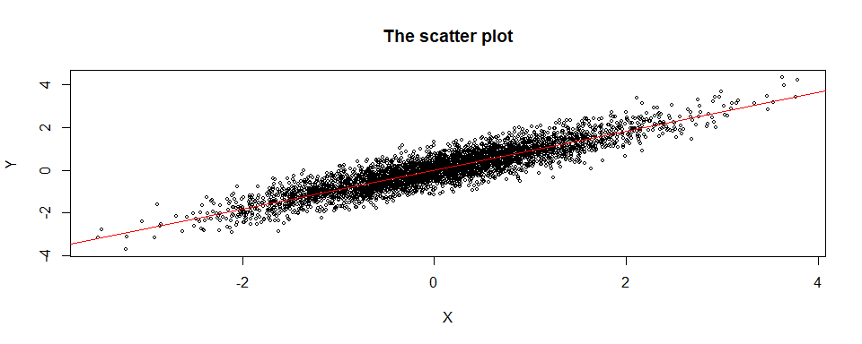

```r
set.seed(22058)

# Function to generate the chain
bivarchain <- function(X,N){
  mu1 <- mu2 <- 0;sigma1 <- sigma2 <- 1;rho <- 0.9
  for (i in 2:N){
    x2 <- X[i-1,2]
    m1 <- mu1+rho*(x2-mu2)*sigma1/sigma2
    s1 <- sqrt(1-rho^2)*sigma1
    X[i,1] <- rnorm(1,m1,s1)
    x1 <- X[i,1]
    m2 <- mu2+rho*(x1-mu1)*sigma2/sigma1
    s2 <- sqrt(1-rho^2)*sigma2
    X[i,2] <- rnorm(1,m2,s2)
  }
  return(X)
}

# Initialize constants and parameters
N <- 5000 # Length of chain
burn <- 1000 # Burn-in length
X <- matrix(0,N,2) # The chain, a bivariate sample

mu1 <- mu2 <- 0 # The initial value
X[1,] <- c(mu1, mu2)
X <- bivarchain(X,N)
b <- burn+1
x <- X[b:N,1];y <- X[b:N,2]
# Draw the scatter plot
plot(x,y,main="The scatter plot",cex=.5,xlab="X", ylab="Y", ylim=range(y))

# Fit a simple linear regression model
fit <- lm(y~x)
abline(fit,col="red")
```

```r
summary(fit)
```

```
##
## Call:
## lm(formula = y ~ x)
##
## Residuals:
##      Min       1Q   Median       3Q      Max
## -1.46808 -0.29163 -0.00585  0.28070  1.47860
##
## Coefficients:
##             Estimate Std. Error t value Pr(>|t|)
## (Intercept) 0.003187   0.006869   0.464    0.643
## x           0.908844   0.006797 133.706   <2e-16 ***
## ---
## Signif. codes:  0 '***' 0.001 '**' 0.01 '*' 0.05 '.' 0.1 ' ' 1
##
## Residual standard error: 0.4334 on 3998 degrees of freedom
## Multiple R-squared:  0.8172, Adjusted R-squared:  0.8172
## F-statistic: 1.788e+04 on 1 and 3998 DF,  p-value: < 2.2e-16
```

- The simple linear regression model is

  $$\hat Y=0.0032+0.9088X.$$
  We can find that the parameter $\beta_1=0.9088$ is close to the correlation 0.9.
- Then check the residuals of the model for normality and constant variance.

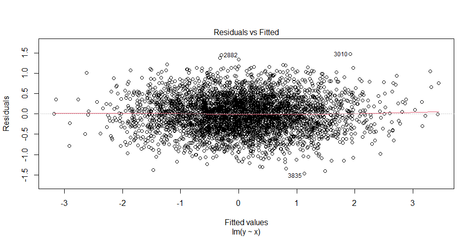

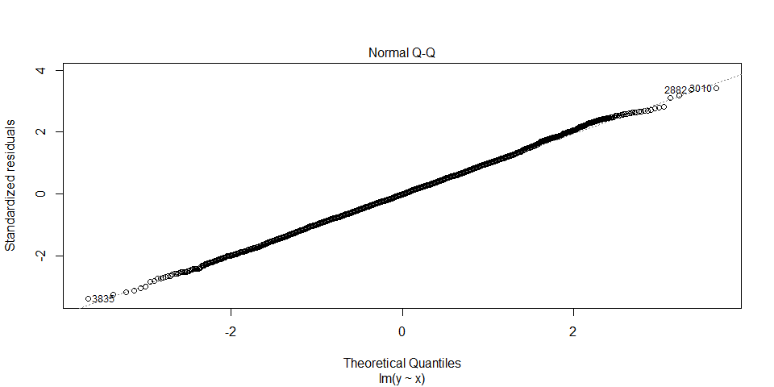

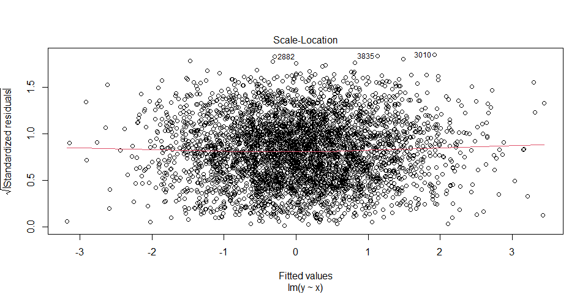

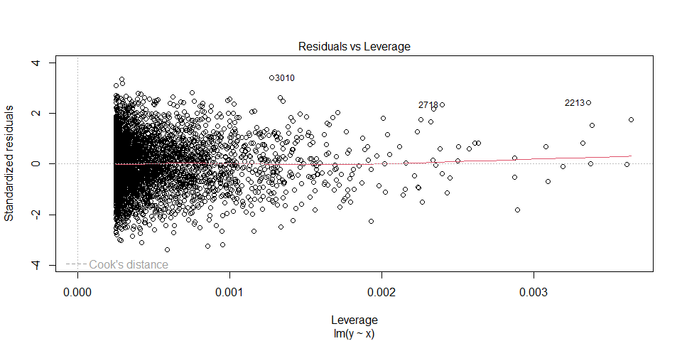

```r
plot(fit)
```

```r
# The cor.test between x and the absolute residuals
abse<-abs(fit$residuals)
cor.test(x,abse,alternative="two.sided",method="spearman",conf.level=0.95)
```

```
##
##  Spearman's rank correlation rho
##
## data:  x and abse
## S = 1.0499e+10, p-value = 0.3204
## alternative hypothesis: true rho is not equal to 0
## sample estimates:
##        rho
## 0.01571621
```

- According to the results above, we can draw the conclusions:
  - The error term are normally distributed according to the Q-Q plot;
  - The model has constant variance.
    - The scatters of **(Standardized)Residuals** and **Fitted values** show that the residuals are in the interval $[-2,2]$ basically;
    - Moreover, the p-value of cor.test between $X$ and the absolute residuals is $0.3204>0.05$. Under the significance level 0.05, we can believe that $X$ and absolute residuals are uncorrelated.

```r
# Monitor the convergence of the chains
# The Gelman-Rubin method
Gelman.Rubin <- function(psi) {
  # psi[i,j] is the statistic psi(X[i,1:j])
  # for chain in i-th row of X
  psi <- as.matrix(psi)
  n <- ncol(psi);k <- nrow(psi)
  psi.means <- rowMeans(psi)
  B <- n*var(psi.means) # between variance est.
  psi.w <- apply(psi,1,"var") # within variances
  W <- mean(psi.w) # within est.
  v.hat <- W*(n-1)/n+(B/n) # upper variance est.
  r.hat <- v.hat/W # G-R statistic
  return(r.hat)
}

# Initialize constants and parameters
mu1 <- mu2 <- c(-5,-1,0,5) # Set the different initial value
x1 <- matrix(0,4,N)
y1 <- matrix(0,4,N)

for(i in 1:4){
  X1 <- matrix(0,N,2)# The chain, a bivariate sample
  X1[1,] <- c(mu1[i], mu2[i])
  X1 <- bivarchain(X1,N)
  x1[i,] <- X1[,1]
  y1[i,] <- X1[,2]
}

# Compute diagnostic statistics
psix <- t(apply(x1, 1, cumsum))
psiy <- t(apply(y1, 1, cumsum))
for(i in 1:nrow(psix)){
  psix[i,] <- psix[i,]/(1:ncol(psix))
}
for(i in 1:nrow(psiy)){
  psiy[i,] <- psiy[i,]/(1:ncol(psiy))
}
print(c(X=Gelman.Rubin(psix),Y=Gelman.Rubin(psiy)))
```

```
##        X        Y
## 1.192815 1.197521
```

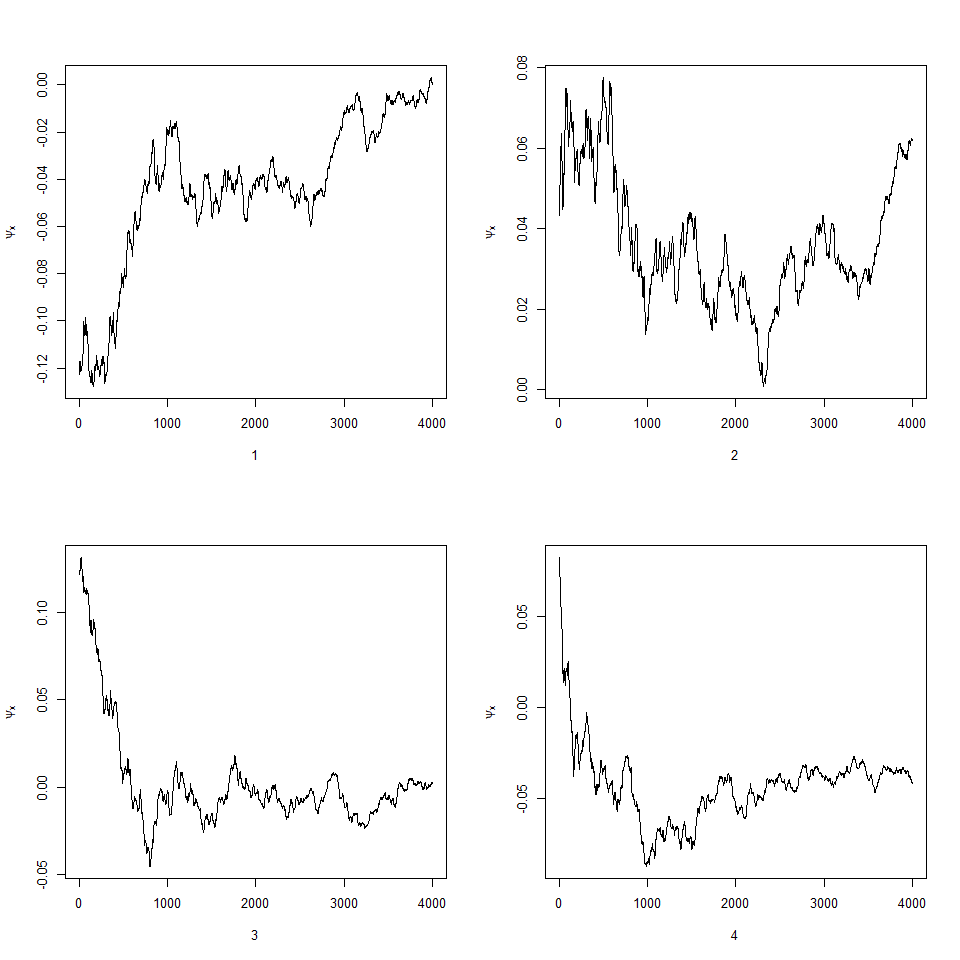

```r
# Plot psi for the four chains
par(mfrow=c(2,2))
for(i in 1:4){
  plot(psix[i,b:N],type="l",xlab=i,ylab=bquote(psi[x]))
}
```

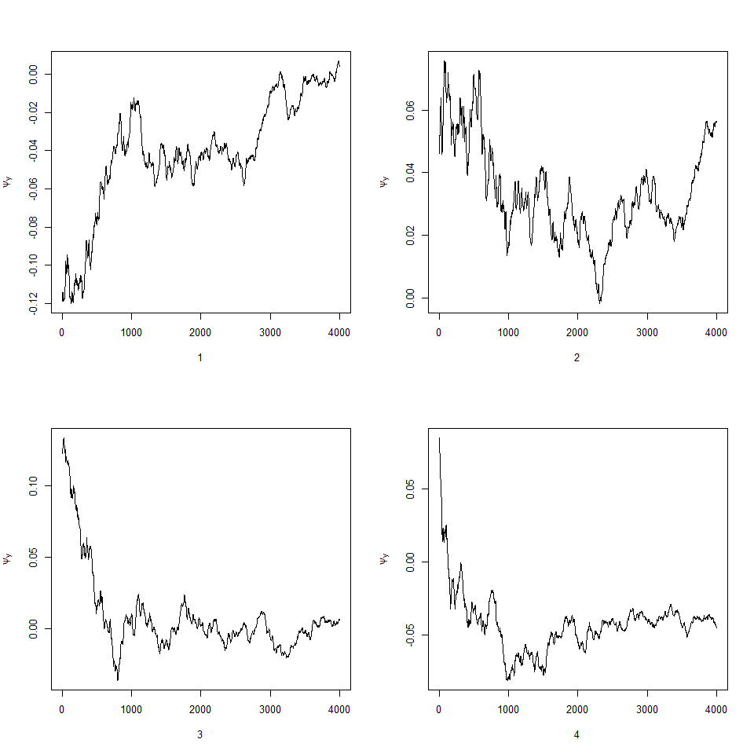

```r
for(i in 1:4){
  plot(psiy[i,b:N],type="l",xlab=i,ylab=bquote(psi[y]))
}
```

```r
par(mfrow=c(1,1)) #restore default
```

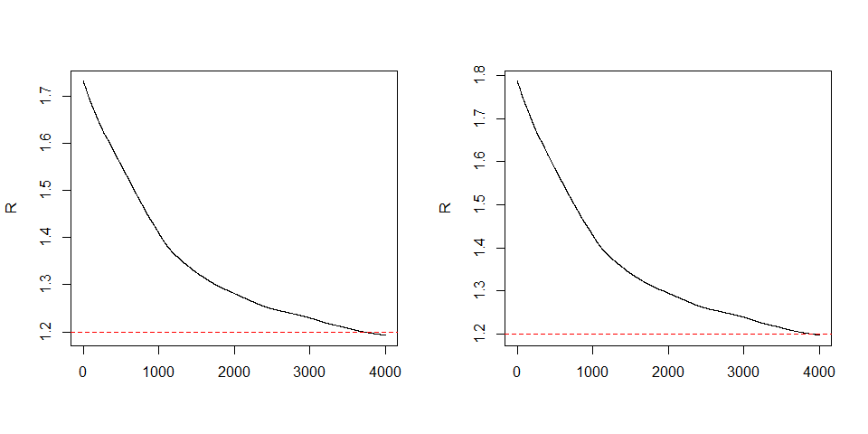

```r
# Plot the sequence of R-hat statistics
rhatx <- rhaty <-rep(0,N)
for(j in b:N){
  rhatx[j] <- Gelman.Rubin(psix[,1:j])
  rhaty[j] <- Gelman.Rubin(psiy[,1:j])
}
par(mfrow=c(1,2))
plot(rhatx[b:N], type="l", xlab="", ylab="R")
abline(h=1.2, lty=2, col="red")
plot(rhaty[b:N], type="l", xlab="", ylab="R")
abline(h=1.2, lty=2, col="red")
```

```r
par(mfrow=c(1,1))

# Clean the memory of the variables
rm(list=ls())
```

# Homework 8

## Exercise 1

Testing the mediating effects. Consider the models
$$M=a_M+\alpha X+e_M,$$
$$Y=a_Y+\beta M+\gamma X+e_Y,$$
$$e_M,e_Y \sim N(0,1).$$
And $e_M,e_Y$ are independent.

The hypothesis testing is
$$H_0:\alpha\beta=0\quad
H_1:\alpha\beta\neq0.$$

The test statistics is
$$T=\frac{\hat{\alpha}\hat{\beta}}{\hat{se}(\hat{\alpha}\hat{\beta})}=\frac{\hat{\alpha}\hat{\beta}}{\sqrt{\hat{\alpha}^2\hat{s}_\beta^2+\hat{\beta}^2\hat{s}_\alpha^2}}$$
while $s_\alpha$ and $s_\beta$ are the standard deviations of $\alpha$ and $\beta$ respectively.

We can implement the permutation test under the following conditions:

- Condition $1$: $\alpha=0,\beta\neq0$. In this situation, $X$ and $M$ are independent, which means that any permutation of $X$ and $M$ are independent;
- Condition $2$: $\beta=0,\alpha\neq0$. In this situation, $M$ and $Y$ are independent, which means that any permutation of $M$ and $Y$ are independent;
- Condition $3$: $\alpha=0,\beta=0$. In this situation,
  - $M$ and $X$ are independent;
  - $M$ and $Y$ are independent.

Set the real values are

- $\alpha=0,\beta=0,\gamma=1,a_M=0.5,a_Y=1$
- $\alpha=0,\beta=1,\gamma=1,a_M=0.5,a_Y=1$
- $\alpha=1,\beta=0,\gamma=1,a_M=0.5,a_Y=1$

Then implement permutation test for each situation of parameter under the three conditions above.

```r
set.seed(123)

# The function to generate the random sample
RSample <- function(n,alpha,beta){
  X <- runif(n,10,20)
  gamma <- 1;aM <- 0.5;aY <- 1
  M <- aM+alpha*X+rnorm(n)
  Y <- aY+beta*M+gamma*X+rnorm(n)
  return(list(X,M,Y))
}

# The function of test statistics computation
Ttest <- function(X,M,Y){
  fit1 <- summary(lm(M~X))
  fit2 <- summary(lm(Y~X+M))
  a <- fit1$coefficients[2,1]
  sea <- fit1$coefficients[2,2]
  b <- fit2$coefficients[3,1]
  seb <- fit2$coefficients[3,2]
  return(a*b/((a*seb)^2+(b*sea)^2)^0.5)
}

# The function to implement the test hypothesis
Imptest <- function(N,n,X,M,Y,T0){
  T1 <- T2 <- T3 <- numeric(N)
  # Condition 1
  for(i in 1:N){
    n1 <- sample(1:n, size=n, replace=FALSE)
    n2 <- sample(1:n, size=n, replace=FALSE)
    X1 <- X[n1];M1 <- M[n2];Y1 <- Y[n2]
    T1[i] <- Ttest(X1,M1,Y1)
  }
  # Condition 2
  for(i in 1:N){
    n1 <- sample(1:n, size = n, replace = FALSE)
    n2 <- sample(1:n, size = n, replace = FALSE)
    X2 <- X[n1];M2 <- M[n1];Y2 <- Y[n2]
    T2[i] <- Ttest(X2,M2,Y2)
  }
  # Condition 3
  for(i in 1:N){
    n1 <- sample(1:n, size = n, replace = FALSE)
    n2 <- sample(1:n, size = n, replace = FALSE)
    M3 <- M[n1];X3 <- X[n2];Y3 <- Y[n2]
    T3[i] <- Ttest(X3,M3,Y3)
  }
  # The p-value of Condition1
  p1 <- mean(abs(c(T0,T1))>abs(T0))
  # The p-value of Condition2
  p2 <- mean(abs(c(T0,T2))>abs(T0))
  # The p-value of Condition3
  p3 <- mean(abs(c(T0,T3))>abs(T0))
  return(c(p1,p2,p3))
}

N <- 1000 # The number of simulation
n <- 100 # The number of random sample
T0 <- numeric(3)
p <- matrix(0,3,3)
# The real values of parameters
alpha <- c(0,0,1);beta <- c(0,1,0)

for(i in 1:3){
  result <- RSample(n,alpha[i],beta[i])
  X <- result[[1]]
  M <- result[[2]]
  Y <- result[[3]]
  # The original value of test statistics
  T0[i] <- Ttest(X,M,Y)
  p[i,] <- Imptest(N,n,X,M,Y,T0[i])
}
```

Output the table of p-values for the permutation tests above.

```r
# Result reporting
colnames(p) <- c("Condition 1","Condition 2","Condition 3")
rownames(p) <- c("alpha=0,beta=0","alpha=0,beta=1","alpha=1,beta=0")
p
```

```
##                Condition 1 Condition 2 Condition 3
## alpha=0,beta=0  0.77022977   0.4045954 0.635364635
## alpha=0,beta=1  0.02097902   0.0000000 0.001998002
## alpha=1,beta=0  0.68331668   0.7032967 0.479520480
```

```r
# Clean the memory of the variables
rm(list=ls())
```

According to the output, none of the permutation tests under the three conditions can control the type I error very well.

## Exercise 2

```r
set.seed(22058)

# The function to solve the alpha
solve <- function(N,b1,b2,b3,f0){
  x1 <- rpois(N,1)
  x2 <- rexp(N,1)
  x3 <- rbinom(N,1,0.5)
  g <- function(alpha){
    tmp <- exp(-alpha-b1*x1-b2*x2-b3*x3)
    p <- 1/(1+tmp)
    mean(p) - f0
  }
  solution <- uniroot(g,c(-50,0))
  return(round(unlist(solution),5)[1])
}

N <- 1e6;b1 <- 0;b2 <- 1;b3 <- -1
f0 <- c(0.1,0.01,0.001,0.0001)
alpha <- numeric(length(f0))
for(i in 1:length(f0)){
  alpha[i] <- solve(N,b1,b2,b3,f0[i])
}
result <- rbind(f0,alpha)
rownames(result) <- c("f0","alpha")
result
```

```
##           [,1]     [,2]     [,3]      [,4]
## f0     0.10000  0.01000  0.00100   0.00010
## alpha -3.16772 -6.08159 -8.72513 -11.29837
```

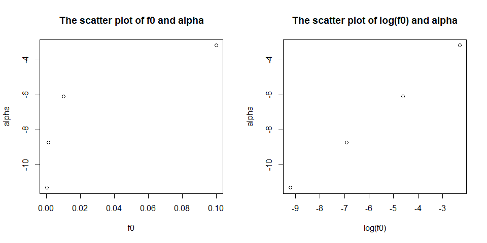

```r
par(mfrow=c(1,2))
# Draw the scatter plot of f0 and alpha
plot(f0,alpha,main="The scatter plot of f0 and alpha")
# Draw the scatter plot of log(f0) and alpha
plot(log(f0),alpha,main="The scatter plot of log(f0) and alpha")
```

```r
par(mfrow=c(1,1))

# Clean the memory of the variables
rm(list=ls())
```

According to the plots, we can get that the relationship between $\log(f_0)$ and $\alpha$ is linear.

# Homework 9

## Class work

- **MLE**

  The sample $x_i\sim Exp(\lambda),u_i\leq x_i\leq v_i,i=1,...,n$, and they are all independent. So we have
  $$f_\lambda(x)=\lambda e^{-\lambda
  x},x>0,$$
  $$F_\lambda(x)=1-e^{-\lambda
  x},x>0.$$

  The likelihood function is
  $$\begin{align*}
  L(\lambda)=&\prod_{i=1}^n p_{\lambda}(u_i\leq x_i\leq v_i)\\
  =&\prod_{i=1}^n(F_\lambda(v_i)-F_\lambda(u_i))\\
  =&\prod_{i=1}^n(1-e^{-\lambda v_i}-1+e^{-\lambda u_i})\\
  =&\prod_{i=1}^n(e^{-\lambda u_i}-e^{-\lambda v_i}),
  \end{align*}$$
  $$l(\lambda)=\log{L(\lambda)}=\sum_{i=1}^n\log(e^{-\lambda
  u_i}-e^{-\lambda v_i}),$$
  $$\frac{\partial l(\lambda)}{\partial\lambda}
  =\sum_{i=1}^n \frac{v_ie^{-\lambda v_i}-u_ie^{-\lambda u_i}}{e^{-\lambda
  u_i}-e^{-\lambda v_i}}=0.$$
- **EM algorithm**

  $$L(\lambda)=\prod_{i=1}^n \lambda
  e^{-\lambda x_i}=\lambda^n e^{-\lambda\sum_{i=1}^nx_i},$$

  $$l(\lambda)=\log(L(\lambda))=n\log\lambda-\lambda\sum_{i=1}^nx_i.$$

  Let $\hat{x}_i^{(0)}=E_{\hat{\lambda}_0}[x_i|u_i,v_i]$, so we can get that
  $$l(\lambda,\hat{\lambda}_0)=n\log\lambda-\lambda\sum_{i=1}^n
  \hat{x}_i^{(0)}.$$
  $$\frac{\partial
  l(\lambda,\hat{\lambda}_0)}{\partial\lambda}=\frac{n}{\lambda}-\sum_{i=1}^n
  \hat{x}_i^{(0)}=0,$$
  $$\hat{\lambda}_1=\frac{n}{\sum_{i=1}^n
  \hat{x}_i^{(0)}}.$$
  Then the conditional probability density function of $x_i$ is

  $$p(x_i|u_i,v_i)=\frac{\lambda e^{-\lambda
  x_i}}{\int_{u_i}^{v_i}\lambda e^{-\lambda x}dx}
  =\frac{\lambda e^{-\lambda x_i}}{e^{-\lambda u_i}-e^{-\lambda
  v_i}}.$$
  $$\begin{align*}
  E(x_i|u_i,v_i)
  =&\int_{u_i}^{v_i}x_i p(x_i|u_i,v_i)dx_i\\
  =&\int_{u_i}^{v_i}x_i \frac{\lambda e^{-\lambda x_i}}{e^{-\lambda
  u_i}-e^{-\lambda v_i}}dx_i\\
  =&\frac{u_ie^{-\lambda u_i}-v_ie^{-\lambda v_i}}{e^{-\lambda
  u_i}-e^{-\lambda v_i}}+\frac{1}{\lambda}.
  \end{align*}$$

  Set the initial value of the parameter is $\hat \lambda_0$, so
  $$\hat{x}_i^{(0)}=\frac{u_ie^{-\hat \lambda_0
  u_i}-v_ie^{-\hat \lambda_0 v_i}}{e^{-\hat \lambda_0 u_i}-e^{-\hat
  \lambda_0 v_i}}+\frac{1}{\hat \lambda_0},$$

  $$\hat{\lambda}_1
  =\frac{n}{\sum_{i=1}^n \frac{u_ie^{-\hat \lambda_0 u_i}-v_ie^{-\hat
  \lambda_0 v_i}}{e^{-\hat \lambda_0 u_i}-e^{-\hat \lambda_0
  v_i}}+\frac{n}{\hat \lambda_0}}.$$

  So we can get the recursive formula
  $$\hat{\lambda}_{k}
  =\frac{n}{\sum_{i=1}^n \frac{u_ie^{-\hat \lambda_{k-1} u_i}-v_ie^{-\hat
  \lambda_{k-1} v_i}}{e^{-\hat \lambda_{k-1} u_i}-e^{-\hat \lambda_{k-1}
  v_i}}+\frac{n}{\hat \lambda_{k-1}}},k=1,2,...$$

  Prove the convergency of EM algorithm.
  $$\hat{\lambda}_{k}
  =\frac{1}{\frac{1}{n}\sum_{i=1}^n \frac{u_ie^{-\hat \lambda_{k-1}
  u_i}-v_ie^{-\hat \lambda_{k-1} v_i}}{e^{-\hat \lambda_{k-1}
  u_i}-e^{-\hat \lambda_{k-1} v_i}}+\frac{1}{\hat
  \lambda_{k-1}}},k=1,2,...$$

  Let
  $$g(x)=\frac{1}{n}\sum_{i=1}^n
  \frac{u_ie^{-x u_i}-v_ie^{-x v_i}}{e^{-x u_i}-e^{-x
  v_i}}+\frac{1}{x},x\neq0,$$
  $$T(x)=\frac{1}{g(x)},x\neq0,$$
  so we have $\hat{\lambda}_{k}=T(\hat{\lambda}_{k-1})$.

  $$\begin{align*}
  g'(x)=&\frac{1}{n}\sum_{i=1}^n \frac{(v_i^2e^{-x v_i}-u_i^2e^{-x
  u_i})(e^{-x u_i}-e^{-x v_i})+(u_ie^{-x u_i}-v_ie^{-x v_i})^2}{(e^{-x
  u_i}-e^{-x v_i})^2}-\frac{1}{x^2}\\
  =&\frac{1}{n}\sum_{i=1}^n \frac{(v_i-u_i)^2e^{-x (u_i+v_i)}}{(e^{-x
  u_i}-e^{-x v_i})^2}-\frac{1}{x^2}\\
  =&\frac{1}{n}\sum_{i=1}^n
  \frac{(v_i-u_i)^2}{e^{x(v_i-u_i)}+e^{x(u_i-v_i)}-2}-\frac{1}{x^2},
  \end{align*}$$
  $$\therefore T'(x)=-\frac{g'(x)}{g^2(x)}=-\frac{n\sum_{i=1}^n
  \frac{(v_i-u_i)^2}{e^{x(v_i-u_i)}+e^{x(u_i-v_i)}-2}-\frac{n^2}{x^2}}{(\sum_{i=1}^n
  \frac{u_ie^{x(v_i-u_i)}-v_i}{e^{x(v_i-u_i)}-1}+\frac{n}{x})^2}.$$
  We can get $0<|T'(x)|<1$. According to Lagrange mean value theorem, for $[x,y]$, there exist $\xi\in(x,y)$
  $$T(x)-T(y)=T'(\xi)(x-y).$$
  $$\therefore
  |T(x)-T(y)|=|T'(\xi)||x-y|,$$
  $$\because 0<|T'(\xi)|<1\therefore
  |T(x)-T(y)|\leq|x-y|.$$
  So $T(x)$ is a compressed mapping, the EM algorithm is convergent.

  With the convergency, setting the value of convergence is $\lambda$. So when $k\rightarrow \infty$, we have that
  $$\hat{\lambda}
  =\frac{n}{\sum_{i=1}^n \frac{u_ie^{-\hat \lambda u_i}-v_ie^{-\hat
  \lambda v_i}}{e^{-\hat \lambda u_i}-e^{-\hat \lambda v_i}}+\frac{n}{\hat
  \lambda}},$$

  which is equivalent to
  $$\sum_{i=1}^n
  \frac{u_ie^{-\hat \lambda u_i}-v_ie^{-\hat \lambda v_i}}{e^{-\hat
  \lambda u_i}-e^{-\hat \lambda v_i}}=0.$$
  Therefore, the conclusion is that the results of MLE and EM algorithm are same.

```r
set.seed(22058)
# The data of sample
u <- c(11,8,27,13,16,0,23,10,24,2)
v <- c(12,9,28,14,17,1,24,11,25,3)
n <- length(u)
# MLE
L <- function(lambda){
  tmp <- (v*exp(-lambda*v)-u*exp(-lambda*u))/(exp(-lambda*u)-exp(-lambda*v))
  sum(tmp)
}
lambdaMLE <- uniroot(L,c(0,10))

# EM algorithm
# Set the initial value
lambda0 <- 0
lambdaEM <- 1
while(lambdaEM!=lambda0){
  lambda0 <- lambdaEM
  lambdaEM <- n/(n/lambda0+sum((u*exp(-lambda0*u)-v*exp(-lambda0*v))/(exp(-lambda0*u)-exp(-lambda0*v))))
}

# Result reporting
print(c("MLE"=unlist(lambdaMLE)[1],
        "EM algorithm"=lambdaEM))
```

```
##     MLE.root EM algorithm
##   0.07196821   0.07197350
```

```r
# Clear the memory of the variables
rm(list=ls())
```

- According the output, the numerical solutions of MLE and EM are same.

## 2.1.3 Exercise 4

```r
a <- list(2,2,0,5,8)
is.atomic(unlist(a))
```

```
## [1] TRUE
```

```r
is.atomic(as.vector(a))
```

```
## [1] FALSE
```

```r
is.list(as.vector(a))
```

```
## [1] TRUE
```

```r
# Clear the memory of the variables
rm(list=ls())
```

- *as.vector()* will return the list with no change.
- Vectors come in two flavours: atomic vectors and lists. Lists are vectors but not atomic vectors.

## 2.1.3 Exercise 5

```r
1 == "1"
```

```
## [1] TRUE
```

```r
-1 < FALSE
```

```
## [1] TRUE
```

```r
"one" < 2
```

```
## [1] FALSE
```

When we compare different types they will be coerced to the most flexible type. Types from least to most flexible are: logical, integer, double, and character.

- The double *1* is coerced to character *“1”*, so we have the result that *1==“1”* is true.
- The *FALSE* is coerced to integer *0*, so we have the result that *-1<FALSE* is true.
- The double *2* is coerced to character *“2”* and the ASCII value of *“2”* is less than *“o”*, so we have the result that *“one”<2* is false.

## 2.3.1 Exercise 1

```r
a <- c(1,2,3,4,5)
dim(a)
```

[output not shown]

```r
# Clear the memory of the variables
rm(list=ls())
```

- *dim()* return *Null* when applied to a vector. The function of *dim()* is to return the dimensions, but a vector has no dimension. So the object which *dim()* applied should be a matrix, array or data frame.

## 2.3.1 Exercise 2

```r
a <- matrix(1,5,7)
is.matrix(a)
```

```
## [1] TRUE
```

```r
is.array(a)
```

```
## [1] TRUE
```

```r
class(a)
```

```
## [1] "matrix" "array"
```

```r
# Clear the memory of the variables
rm(list=ls())
```

- *is.array()* will return TRUE because matrix and array are homogeneous.

## 2.4.5 Exercise 1

```r
dfm <- data.frame(x=1:3, y=I(matrix(1:9,nrow=3)))
dfm
```

```
##   x y.1 y.2 y.3
## 1 1   1   4   7
## 2 2   2   5   8
## 3 3   3   6   9
```

```r
attributes(dfm)
```

```
## $names
## [1] "x" "y"
##
## $class
## [1] "data.frame"
##
## $row.names
## [1] 1 2 3
```

- A data frame possesses the attributes that the class and the name of row and column.

## 2.4.5 Exercise 2

```r
as.matrix(dfm)
```

```
##      x y.1 y.2 y.3
## [1,] 1   1   4   7
## [2,] 2   2   5   8
## [3,] 3   3   6   9
```

```r
# Clear the memory of the variables
rm(list=ls())
```

- Matrix and data frame are heterogeneous, but they have the same dimensionality.

## 2.4.5 Exercise 3

```r
a <- data.frame()
nrow(a)
```

```
## [1] 0
```

```r
ncol(a)
```

```
## [1] 0
```

```r
# Clear the memory of the variables
rm(list=ls())
```

- Yes. we can have a data frame with 0 rows or 0 columns.

# Homework 10

## Exercises 2

The function below scales a vector so it falls in the range [0,1]. How would you apply it to every column of a data frame? How would you apply it to every numeric column in a data frame?

## Answer 2

```r
set.seed(22058)
scale01 <- function(x) {
  rng <- range(x, na.rm = TRUE)
  (x - rng[1]) / (rng[2] - rng[1])
}

# Apply to every column of a data frame
# Using the data frame mtcars
attach(mtcars)
result1 <- lapply(mtcars, scale01)
head(as.data.frame(result1))
```

```
##         mpg cyl      disp        hp      drat        wt      qsec vs am gear
## 1 0.4510638 0.5 0.2217511 0.2049470 0.5253456 0.2830478 0.2333333  0  1  0.5
## 2 0.4510638 0.5 0.2217511 0.2049470 0.5253456 0.3482485 0.3000000  0  1  0.5
## 3 0.5276596 0.0 0.0920429 0.1448763 0.5023041 0.2063411 0.4892857  1  1  0.5
## 4 0.4680851 0.5 0.4662010 0.2049470 0.1474654 0.4351828 0.5880952  1  0  0.0
## 5 0.3531915 1.0 0.7206286 0.4346290 0.1797235 0.4927129 0.3000000  0  0  0.0
## 6 0.3276596 0.5 0.3838863 0.1872792 0.0000000 0.4978266 0.6809524  1  0  0.0
##        carb
## 1 0.4285714
## 2 0.4285714
## 3 0.0000000
## 4 0.0000000
## 5 0.1428571
## 6 0.0000000
```

```r
detach(mtcars)

# Apply to every numeric column in a data frame
# Using the data frame iris
attach(iris)
dfmclass <- sapply(iris,is.numeric)
dfmclass <- as.numeric(which(dfmclass==TRUE))
result2 <- lapply(iris[dfmclass],scale01)
head(as.data.frame(result2))
```

```
##   Sepal.Length Sepal.Width Petal.Length Petal.Width
## 1   0.22222222   0.6250000   0.06779661  0.04166667
## 2   0.16666667   0.4166667   0.06779661  0.04166667
## 3   0.11111111   0.5000000   0.05084746  0.04166667
## 4   0.08333333   0.4583333   0.08474576  0.04166667
## 5   0.19444444   0.6666667   0.06779661  0.04166667
## 6   0.30555556   0.7916667   0.11864407  0.12500000
```

```r
detach(iris)

# Clear the memory of the variables
rm(list=ls())
```

## Exercises 1

Use vapply() to:

1. Compute the standard deviation of every column in a numeric data frame.
2. Compute the standard deviation of every numeric column in a mixed data frame. (Hint: you’ll need to use vapply() twice.)

## Answer 1

```r
set.seed(22058)

# a) In a numeric data frame
# Using the data frame mtcars
attach(mtcars)
vapply(mtcars,sd,numeric(1))
```

```
##         mpg         cyl        disp          hp        drat          wt
##   6.0269481   1.7859216 123.9386938  68.5628685   0.5346787   0.9784574
##        qsec          vs          am        gear        carb
##   1.7869432   0.5040161   0.4989909   0.7378041   1.6152000
```

```r
detach(mtcars)

# b) In a mixed data frame
# Using the data frame iris
attach(iris)
dfmclass <- vapply(iris,is.numeric,logical(1))
dfmclass <- as.numeric(which(dfmclass==TRUE))
vapply(iris[dfmclass],sd,numeric(1))
```

```
## Sepal.Length  Sepal.Width Petal.Length  Petal.Width
##    0.8280661    0.4358663    1.7652982    0.7622377
```

```r
detach(iris)

# Clear the memory of the variables
rm(list=ls())
```

## Question 3

Implement a Gibbs sampler to generate a bivariate normal chain $(X_t, Y_t)$ with zero means, unit standard deviations, and correlation 0.9.

- Write an Rcpp function.
- Compare the corresponding generated random numbers with pure R language using the function “qqplot”.
- Compare the computation time of the two functions with the function “microbenchmark”.

## Answer 3

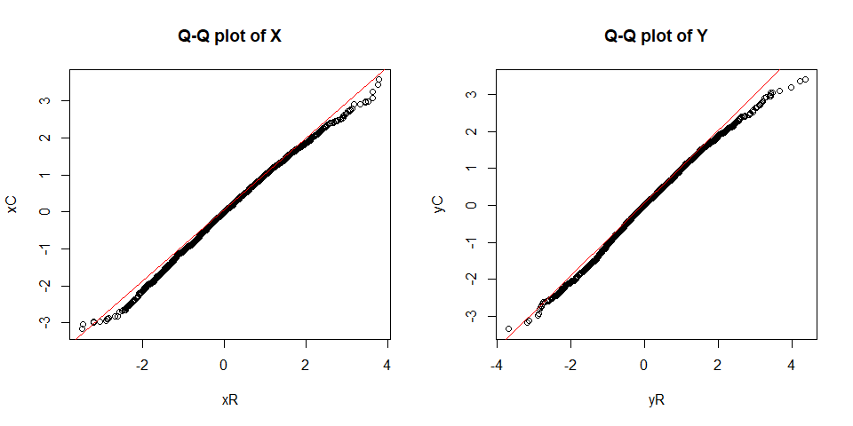

```r
# Rcpp function
library(Rcpp)
cppFunction('NumericMatrix Cbivarchain(double a,double b,int N){
  double mu1,mu2,sigma1,sigma2,rho;
  double x1,x2,m1,s1,m2,s2;
  int i;
  NumericMatrix X(N,2);
  mu1 = mu2 = 0;sigma1 = sigma2 = 1;rho = 0.9;
  X(0,0) = a;X(0,1) = b;
  s1 = sqrt(1-pow(rho,2))*sigma1;
  s2 = sqrt(1-pow(rho,2))*sigma2;
  for(i=1;i<N;i++){
    x2 = X(i-1,1);
    m1 = mu1+rho*(x2-mu2)*sigma1/sigma2;
    X(i,0) = R::rnorm(m1,s1);
    x1 = X(i,0);
    m2 = mu2+rho*(x1-mu1)*sigma2/sigma1;
    X(i,1) = R::rnorm(m2,s2);
  }
  return X;
}')

# R function
Rbivarchain <- function(a,b,N){
  mu1 <- mu2 <- 0;sigma1 <- sigma2 <- 1;rho <- 0.9
  s1 <- sqrt(1-rho^2)*sigma1
  s2 <- sqrt(1-rho^2)*sigma2
  X <- matrix(0,N,2)
  X[1,] <- c(a,b)
  for (i in 2:N){
    x2 <- X[i-1,2]
    m1 <- mu1+rho*(x2-mu2)*sigma1/sigma2
    X[i,1] <- rnorm(1,m1,s1)
    x1 <- X[i,1]
    m2 <- mu2+rho*(x1-mu1)*sigma2/sigma1
    X[i,2] <- rnorm(1,m2,s2)
  }
  return(X)
}

# Generate random numbers
N <- 5000 # Length of chain
burn <- 1000 # Burn-in length
start <- burn+1
a <- b <- 0 # The initial value
XR <- Rbivarchain(a,b,N)
xR <- XR[start:N,1];yR <- XR[start:N,2]
XC <- Cbivarchain(a,b,N)
xC <- XC[start:N,1];yC <- XC[start:N,2]

# Draw Q-Q plots
par(mfrow=c(1,2))
qqplot(xR,xC,main="Q-Q plot of X")
qqline(xR,col="red")
qqplot(yR,yC,main="Q-Q plot of Y")
qqline(yR,col="red")
```

```r
par(mfrow=c(1,1)) #restore default
```

According to the plots above, we can get that the empirical distributions of random numbers $(X_t,Y_t)$ with pure R language and Rcpp function are very close.

```r
# Compare the computation time
library(microbenchmark)
microbenchmark(Rbivarchain=Rbivarchain(a,b,N),
               Cbivarchain=Cbivarchain(a,b,N))
```

```
## Unit: microseconds
##         expr     min       lq      mean   median       uq     max neval
##  Rbivarchain 18925.8 19708.15 24409.583 22019.10 27538.35 46156.3   100
##  Cbivarchain   593.3   598.30   635.687   614.65   625.30  1895.8   100
```

```r
# Clear the memory of the variables
rm(list=ls())
```

According to the result, the the computation time is shorter using Rcpp function than pure R language.